# Exploring the causal inference of shear stress associated DNA methylation on cardiovascular risk

Ruben Methorst, Bsc**, prof. dr. Gerard Pasterkamp, dr. Sander W. Van der Laan

10-02-2020

## Introduction

Here we present the scripts and data corresponding with above stated publication. We performed several in silico analyses, including methylation quantitative trait loci (*cis*-mQTL) analysis using QTLtool v1.1 and Two Sample Mendelian Randomisation (2SMR) using TwoSampleMR v0.4.22.

Data was obtained from several sources. mQTL analysis was performed in genotyping and methylation data from the AtheroExpress Biobank<sup>1</sup>. 2SMR was performed using CARDIoGRAM+C4D<sup>2</sup> and METASTROKE<sup>3</sup> GWAS summary statistics.

## *cis*-mQTL analysis

*cis*-mQTL was perfomed using readily built scripts by S.W. Van der Laan, Associate Professor UMC Utrecht.

### Data preparation

We extracted our regions of interest from the Illumina 450k manifest file. Only looked at our 11 genes of interest and only at CpGs within -2000 TSS and 1st exon. A range of +/- 250kb was used on this region of interest to analyse for mQTLs using QTLtools<sup>4</sup>.

```r
#read data

CPG <- read.delim("CPG.txt", header = FALSE)

Illumina450K <- read_csv("HumanMethylation450_15017482_v1-2.csv")

#extract genes of interest

IlluminaREGIONS <- Illumina450K[grep("KLF4|HOXA5|TMEM184B|ADAMTSL5|KLF3|CMKLR1|PKP4|ACVRL1|DOK4|SPRY2|ENOSF1",
                                  Illumina450K$UCSC_RefGene_Name), ]

Illumina_data <- IlluminaREGIONS[-grep("Body|3'UTR", IlluminaREGIONS$UCSC_RefGene_Group), ]

ROI <- data.frame(Illumina_data$IlmnID, Illumina_data$UCSC_RefGene_Name, Illumina_data$Chromosome_36, Illumina_data$Coordinate_36, Illumina_data$Coordinate_36, Illumina_data$Strand)

#Range, lead, trait column added

range <- numeric(157)

ROI["range"] <- range

ROI$range <- 250000


lead <- numeric(157)
ROI["lead"] <- lead

ROI$lead <- "new_lead"

trait <- numeric(157)
ROI["trait"] <- trait

ROI$trait <- "SS"

#prepare first row

ROI[1, 8] <- "previous_&_new_lead"

#to and from column added

ROI$from <- ROI$Illumina_data.Coordinate_36

ROI$to <- ROI$Illumina_data.Coordinate_36

#change names

colnames(ROI)[1:4] <- c("CpG", "Gene", "Chr", "Location")

#re-order

ROI2 <- ROI[c(1, 2, 3, 4, 10, 11, 7, 8, 9)]

#from to change values to TSS and -/+ 250kb

REGIONS <- ROI2

REGIONS$from[REGIONS$from %like% "^1590"] <- "158771722"
REGIONS$from[REGIONS$from %like% "^383"] <- "38092185"
REGIONS$from[REGIONS$from %like% "^271"] <- "27149812"
REGIONS$from[REGIONS$from %like% "^109"] <- "109291576"
REGIONS$from[REGIONS$from %like% "^107"] <- "107257216"
REGIONS$from[REGIONS$from %like% "^505"] <- "50342380"
REGIONS$from[REGIONS$from %like% "^798"] <- "79813087"
REGIONS$from[REGIONS$from %like% "^560"] <- "56077886"
REGIONS$from[REGIONS$from %like% "^702"] <- "702676"
REGIONS$from[REGIONS$from %like% "^703"] <- "702676"
REGIONS$from[REGIONS$from %like% "^146"] <- "1464019"
REGIONS$from[REGIONS$from %like% "^369"] <- "36998962"


REGIONS$to[REGIONS$to %like% "^1590"] <- "159021722"
REGIONS$to[REGIONS$to %like% "^383"] <- "38342185"
REGIONS$to[REGIONS$to %like% "^271"] <- "27399812"
REGIONS$to[REGIONS$to %like% "^109"] <- "109541576"
REGIONS$to[REGIONS$to %like% "^107"] <- "107507216"
REGIONS$to[REGIONS$to %like% "^505"] <- "50592380"
REGIONS$to[REGIONS$to %like% "^798"] <- "80063087"
REGIONS$to[REGIONS$to %like% "^560"] <- "56327886"
REGIONS$to[REGIONS$to %like% "^702"] <- "952676"
REGIONS$to[REGIONS$to %like% "^703"] <- "952676"
REGIONS$to[REGIONS$to %like% "^146"] <- "1714019"
REGIONS$to[REGIONS$to %like% "^369"] <- "37248962"

Inputfile <- REGIONS


#export

#write.table(ROI2, file = "ROI", sep = " ", row.names = FALSE, col.names = FALSE)
```

### Input data

```r
Inputfile %>%
  kable() %>%
  kable_styling(bootstrap_options = c("striped", "condensed"), font_size = 12, fixed_thead = T)
```

| CpG | Gene | Chr | Location | from | to | range | lead | trait |
| --- | --- | --- | --- | --- | --- | --- | --- | --- |
| cg00765721 | CCDC148;CCDC148;PKP4;PKP4 | 2 | 159022426 | 158771722 | 159021722 | 250000 | previous_&_new_lead | SS |
| cg00993543 | CCDC148;CCDC148;PKP4;PKP4 | 2 | 159021591 | 158771722 | 159021722 | 250000 | new_lead | SS |
| cg01775379 | PKP4;PKP4 | 2 | 159024510 | 158771722 | 159021722 | 250000 | new_lead | SS |
| cg02001814 | PKP4;CCDC148;PKP4;CCDC148;CCDC148;CCDC148 | 2 | 159021394 | 158771722 | 159021722 | 250000 | new_lead | SS |
| cg03264934 | CCDC148;CCDC148;PKP4;PKP4 | 2 | 159022989 | 158771722 | 159021722 | 250000 | new_lead | SS |
| cg04066396 | PKP4;PKP4 | 2 | 159023157 | 158771722 | 159021722 | 250000 | new_lead | SS |
| cg08444306 | CCDC148;CCDC148;PKP4;PKP4;PKP4;PKP4 | 2 | 159021825 | 158771722 | 159021722 | 250000 | new_lead | SS |
| cg08843298 | CCDC148;CCDC148;PKP4;PKP4 | 2 | 159021558 | 158771722 | 159021722 | 250000 | new_lead | SS |
| cg09072756 | PKP4;PKP4 | 2 | 159051937 | 158771722 | 159021722 | 250000 | new_lead | SS |
| cg10535786 | CCDC148;CCDC148;PKP4;PKP4 | 2 | 159021643 | 158771722 | 159021722 | 250000 | new_lead | SS |
| cg13896783 | CCDC148;CCDC148;PKP4;PKP4 | 2 | 159022122 | 158771722 | 159021722 | 250000 | new_lead | SS |
| cg17648451 | PKP4;PKP4 | 2 | 159094854 | 158771722 | 159021722 | 250000 | new_lead | SS |
| cg19840387 | CCDC148;CCDC148;PKP4;PKP4 | 2 | 159022262 | 158771722 | 159021722 | 250000 | new_lead | SS |
| cg20438915 | PKP4;PKP4 | 2 | 159025540 | 158771722 | 159021722 | 250000 | new_lead | SS |
| cg24519780 | PKP4;PKP4 | 2 | 159035659 | 158771722 | 159021722 | 250000 | new_lead | SS |
| cg27167195 | PKP4;PKP4 | 2 | 159087660 | 158771722 | 159021722 | 250000 | new_lead | SS |
| cg00033516 | FLJ13197;KLF3 | 4 | 38343168 | 38092185 | 38342185 | 250000 | new_lead | SS |
| cg05205842 | KLF3 | 4 | 38349525 | 38092185 | 38342185 | 250000 | new_lead | SS |
| cg05562080 | KLF3;FLJ13197 | 4 | 38342843 | 38092185 | 38342185 | 250000 | new_lead | SS |
| cg09915299 | FLJ13197;KLF3 | 4 | 38343058 | 38092185 | 38342185 | 250000 | new_lead | SS |
| cg14848077 | FLJ13197;KLF3 | 4 | 38343313 | 38092185 | 38342185 | 250000 | new_lead | SS |
| cg16471864 | KLF3;FLJ13197 | 4 | 38342665 | 38092185 | 38342185 | 250000 | new_lead | SS |
| cg17074863 | KLF3 | 4 | 38345149 | 38092185 | 38342185 | 250000 | new_lead | SS |
| cg18361445 | KLF3;FLJ13197 | 4 | 38342769 | 38092185 | 38342185 | 250000 | new_lead | SS |
| cg22453435 | FLJ13197;KLF3 | 4 | 38343825 | 38092185 | 38342185 | 250000 | new_lead | SS |
| cg24279243 | KLF3 | 4 | 38352954 | 38092185 | 38342185 | 250000 | new_lead | SS |
| cg27283052 | KLF3;FLJ13197 | 4 | 38342757 | 38092185 | 38342185 | 250000 | new_lead | SS |
| cg00969405 | HOXA5 | 7 | 27150966 | 27149812 | 27399812 | 250000 | new_lead | SS |
| cg01323381 | HOXA5 | 7 | 27150789 | 27149812 | 27399812 | 250000 | new_lead | SS |
| cg01370449 | HOXA5 | 7 | 27149894 | 27149812 | 27399812 | 250000 | new_lead | SS |

[output cut: 127 more lines]

### Results

#### Nominal results

Fraction of the filtered post QC-results (*full table available upon request*)

```r
temp <- list.files(pattern = "DEFAULT.nominal")

mQTL_data_nom <- lapply(temp, read.csv)

mQTL_data_nom <- do.call(rbind, mQTL_data_nom)

head(mQTL_data_nom) %>% dplyr::mutate_if(is.numeric, funs(as.character(signif(., 3)))) %>%
    kable(.) %>%
  kable_styling(bootstrap_options = c("striped", "condensed"), font_size = 12, fixed_thead = T)
```

ProbeID

VARIANT

Chr

BP

OtherAlleleB

CodedAlleleA

MAF

MAC

CAF

HWE

Info

Imputation

N

Distance_VARIANT_CpG

Strand

Chr_CpG

BP_CpG

ProbeType

GeneName_UCSC

AccessionID_UCSC

GeneGroup_UCSC

CpG_Island_Relation_UCSC

Phantom

DMR

Enhancer

HMM_Island

RegulatoryFeatureName

RegulatoryFeatureGroup

DHS

Beta

SE

Nominal_P

Bonferroni

BenjHoch

Q

cg23876203

rs17427693

7

27200000

G

C

0.0771

222

0.0771

1

0.932

imputed

1440

-13400

7

27200000

II

HOXA3

NM_153631;NM_030661

5’UTR;TSS1500

N_Shelf

NA

NA

NA

NA

NA

NA

NA

-2.57

0.124

9.16e-96

5.03e-90

5.03e-90

Not_calculated._Throws_an_error_when_p-value_is_infinite_or_NA._NEED_FIXING

cg23876203

rs17471860

7

27200000

C

A

0.0774

223

0.0774

1

0.93

imputed

1440

-6970

7

27200000

II

HOXA3

NM_153631;NM_030661

5’UTR;TSS1500

N_Shelf

NA

NA

NA

NA

NA

NA

NA

-2.57

0.126

2.3e-93

1.26e-87

6.32e-88

Not_calculated._Throws_an_error_when_p-value_is_infinite_or_NA._NEED_FIXING

cg23876203

rs112622479

7

27200000

G

A

0.0728

210

0.0728

0.844

0.903

imputed

1440

0

7

27200000

II

HOXA3

NM_153631;NM_030661

5’UTR;TSS1500

N_Shelf

NA

NA

NA

NA

NA

NA

NA

-2.73

0.135

3.19e-91

1.75e-85

5.84e-86

Not_calculated._Throws_an_error_when_p-value_is_infinite_or_NA._NEED_FIXING

cg26364809

rs2428433

7

27100000

T

C

0.0988

284

0.0988

0.0994

0.976

imputed

1440

-357

7

27100000

II

NA

NA

NA

N_Shore

NA

RDMR

NA

NA

NA

NA

NA

-0.574

0.0408

3.57e-45

1.96e-39

2.18e-40

Not_calculated._Throws_an_error_when_p-value_is_infinite_or_NA._NEED_FIXING

cg26364809

rs78922934

7

27100000

GATTT

G

0.0983

283

0.0983

0.0992

0.978

imputed

1440

-388

7

27100000

II

NA

NA

NA

N_Shore

NA

RDMR

NA

NA

NA

NA

NA

-0.574

0.0408

3.57e-45

1.96e-39

2.18e-40

Not_calculated._Throws_an_error_when_p-value_is_infinite_or_NA._NEED_FIXING

cg26364809

rs2465276

7

27100000

G

A

0.0984

283

0.0984

0.0992

0.979

imputed

1440

-557

7

27100000

II

NA

NA

NA

N_Shore

NA

RDMR

NA

NA

NA

NA

NA

-0.574

0.0408

3.57e-45

1.96e-39

2.18e-40

Not_calculated._Throws_an_error_when_p-value_is_infinite_or_NA._NEED_FIXING

#### Permutation results

Filtered post QC-results

```r
temp <- list.files(pattern = "perm.Q")

mQTL_data_perm <- lapply(temp, read.csv)

mQTL_data_perm <- do.call(rbind, mQTL_data_perm)

mQTL_data_perm %>% dplyr::mutate_if(is.numeric, funs(as.character(signif(., 3)))) %>%
    kable(.) %>%
  kable_styling(bootstrap_options = c("striped", "condensed"), font_size = 12, fixed_thead = T)
```

ProbeID

VARIANT

Chr

BP

OtherAlleleB

CodedAlleleA

MAF

MAC

CAF

HWE

Info

Imputation

N

Distance_VARIANT_CpG

Strand

Chr_CpG

BP_CpG

ProbeType

GeneName_UCSC

AccessionID_UCSC

GeneGroup_UCSC

CpG_Island_Relation_UCSC

Phantom

DMR

Enhancer

HMM_Island

RegulatoryFeatureName

RegulatoryFeatureGroup

DHS

Beta

SE

Nominal_P

Perm_P

ApproxPerm_P

Bonferroni

BenjHoch

Q

cg23876203

rs17427693

7

27200000

G

C

0.0771

222

0.0771

1

0.932

imputed

1440

-13400

7

27200000

II

HOXA3

NM_153631;NM_030661

5’UTR;TSS1500

N_Shelf

NA

NA

NA

NA

NA

NA

NA

-2.57

0.124

9.16e-96

0.000999

9.25e-72

5.73e-69

5.73e-69

2.12e-69

cg26364809

rs2428433

7

27100000

T

C

0.0988

284

0.0988

0.0994

0.976

imputed

1440

-357

7

27100000

II

NA

NA

NA

N_Shore

NA

RDMR

NA

NA

NA

NA

NA

-0.574

0.0408

3.57e-45

0.000999

1.77e-35

1.1e-32

5.48e-33

2.02e-33

cg22772418

rs2285724

7

27200000

G

A

0.387

1110

0.613

0.541

0.95

imputed

1440

0

7

27200000

II

HOXA11AS

NR_002795

Body

N_Shore

NA

RDMR

TRUE

NA

7:27227235-27227416

Unclassified_Cell_type_specific

TRUE

-0.332

0.0259

5.89e-38

0.000999

6.14e-31

3.81e-28

1.27e-28

4.68e-29

cg15700661

rs213518

7

26900000

T

C

0.138

397

0.138

0.911

0.995

imputed

1440

-17900

7

2.7e+07

II

NA

NA

NA

NA

NA

NA

TRUE

NA

NA

NA

NA

0.435

0.0364

3.24e-33

0.000999

1.28e-25

7.94e-23

1.98e-23

7.32e-24

cg21404045

rs2189239

7

27200000

C

T

0.0762

219

0.0762

1

0.933

imputed

1440

5040

7

27200000

I

NA

NA

NA

Island

NA

NA

NA

7:27198099-27198983

NA

NA

TRUE

0.529

0.0588

1.21e-19

0.000999

3.38e-14

2.09e-11

4.19e-12

1.55e-12

cg20884887

rs6949451

7

27200000

C

T

0.47

1350

0.47

0.459

0.843

imputed

1440

6760

7

27200000

I

NA

NA

NA

N_Shore

NA

NA

NA

7:27174681-27174845

7:27207963-27208290

Unclassified_Cell_type_specific

NA

0.746

0.0836

2.43e-19

0.000999

4.84e-14

3e-11

5e-12

1.85e-12

cg18245160

rs2071265:27238691:C:G

7

27200000

C

G

0.0684

197

0.932

0.835

0.969

imputed

1440

-5680

7

27200000

II

NA

NA

NA

N_Shore

NA

NA

NA

NA

7:27244365-27244762

Unclassified_Cell_type_specific

NA

-0.378

0.0551

3.39e-12

0.000999

1.81e-08

1.12e-05

1.6e-06

5.91e-07

cg24169822

rs3735528:27183468:G:T

7

27200000

G

T

0.262

753

0.738

0.245

0.929

imputed

1440

12500

7

27200000

II

HOXA4

NM_002141

TSS1500

S_Shore

NA

NA

TRUE

7:27136937-27137577

7:27170014-27171090

Promoter_Associated

NA

-0.177

0.0267

1.81e-11

0.000999

1.5e-07

9.29e-05

1.16e-05

4.28e-06

cg25952581

rs3735528:27183468:G:T

7

27200000

G

T

0.262

753

0.738

0.245

0.929

imputed

1440

-12500

7

27200000

II

HOXA4

NM_002141

TSS1500

S_Shore

NA

DMR

TRUE

7:27136937-27137577

7:27170014-27171090

Promoter_Associated

TRUE

-0.136

0.0227

1.04e-09

0.000999

1.1e-06

0.000681

7.57e-05

2.79e-05

cg19816811

rs3735530

7

27200000

C

T

0.144

415

0.856

0.455

0.957

imputed

1440

1620

7

27200000

II

HOXA6

NM_024014

TSS1500

N_Shore

NA

NA

NA

7:27153988-27155184

7:27186949-27188385

Unclassified_Cell_type_specific

TRUE

0.435

0.0758

4.92e-09

0.000999

3.53e-06

0.00219

0.000219

8.06e-05

cg08657492

rs3757640

7

27200000

C

T

0.264

761

0.736

0.175

0.927

imputed

1440

11400

7

27200000

II

HOXA4

NM_002141

TSS1500

S_Shore

NA

DMR

TRUE

7:27136937-27137577

7:27170014-27171090

Promoter_Associated

TRUE

-0.219

0.0384

5.98e-09

0.000999

9.81e-06

0.00608

0.000507

0.000187

cg14188840

rs148397727:27232409:CTCCGT:C

7

27200000

CTCCGT

C

0.0751

216

0.0751

0.849

0.928

imputed

1440

12000

7

27200000

I

HOXA10

NM_153715

TSS1500

S_Shore

NA

NA

NA

NA

7:27218624-27220804

Unclassified

NA

0.446

0.0797

1.14e-08

0.000999

9.41e-06

0.00583

0.000507

0.000187

cg04321618

rs3757640

7

27200000

C

T

0.264

761

0.736

0.175

0.927

imputed

1440

-11400

7

27200000

II

HOXA4

NM_002141

TSS1500

S_Shore

NA

DMR

TRUE

7:27136937-27137577

7:27170014-27171090

Promoter_Associated

TRUE

-0.312

0.0562

1.38e-08

0.000999

1.13e-05

0.00702

0.00054

0.000199

cg16880946

rs983185

7

27200000

G

A

0.141

406

0.859

0.513

0.963

imputed

1440

-141

7

27200000

II

HOXA6

NM_024014

TSS1500

N_Shore

NA

NA

NA

7:27153988-27155184

NA

NA

TRUE

0.294

0.0524

9.51e-09

0.000999

1.51e-05

0.00938

0.000648

0.000239

cg19623360

rs4722665

7

27200000

A

G

0.295

849

0.295

0.849

0.938

imputed

1440

5400

7

27200000

I

NA

NA

NA

S_Shore

NA

RDMR

NA

7:27158048-27158728

NA

NA

NA

0.227

0.0416

2.34e-08

0.000999

1.57e-05

0.00972

0.000648

0.000239

cg04988219

rs10248288

7

27300000

C

G

0.451

1300

0.549

0.489

0.901

imputed

1440

-379

7

27300000

II

NA

NA

NA

N_Shore

NA

NA

NA

NA

NA

NA

NA

-0.219

0.0416

6.81e-08

0.000999

4.44e-05

0.0275

0.00172

0.000634

cg11097541

rs2071243

7

27200000

C

T

0.474

1360

0.474

0.459

0.841

imputed

1440

-91

7

27200000

II

NA

NA

NA

N_Shore

NA

DMR

NA

7:27174681-27174845

7:27207963-27208290

Unclassified_Cell_type_specific

NA

0.161

0.0311

1.01e-07

0.000999

8.06e-05

0.0499

0.00294

0.00108

cg02643054

rs17437495:27224963:T:C

7

27200000

T

C

0.0772

222

0.0772

1

0.905

imputed

1440

18400

7

27200000

II

HOXA9

NM_152739

TSS1500

S_Shore

NA

DMR

NA

7:27172191-27173627

NA

NA

NA

0.34

0.0658

1.22e-07

0.000999

0.000101

0.0623

0.00346

0.00128

cg24979288

rs10228276

7

27200000

G

A

0.168

483

0.832

0.0369

0.935

imputed

1440

-4850

7

27200000

II

NA

NA

NA

N_Shelf

NA

RDMR

NA

NA

NA

NA

NA

-0.318

0.0629

2.19e-07

0.000999

0.000113

0.0702

0.0037

0.00136

cg19817912

rs59278341

7

27200000

GC

G

0.33

950

0.67

0.404

0.926

imputed

1440

-234

7

27200000

II

HOXA3

NM_153631

5’UTR

N_Shore

NA

RDMR

TRUE

7:27129291-27130024

7:27162683-27163732

Unclassified_Cell_type_specific

NA

0.228

0.0469

5.69e-07

0.002

0.000289

0.179

0.00849

0.00313

cg17591595

rs10225507:27170583:C:T

7

27200000

C

T

0.176

507

0.824

0.467

0.951

imputed

1440

-469

7

27200000

II

HOXA4

NM_002141

TSS1500

S_Shore

NA

RDMR

NA

7:27136937-27137577

7:27170014-27171090

Promoter_Associated

TRUE

-0.281

0.0571

4.39e-07

0.000999

0.00029

0.18

0.00849

0.00313

cg23766724

rs4719884

7

27200000

G

A

0.257

740

0.257

0.89

0.949

imputed

1440

-61

7

27200000

II

NA

NA

NA

S_Shore

NA

CDMR

NA

NA

NA

NA

NA

-0.121

0.0254

1.04e-06

0.000999

0.000301

0.187

0.00849

0.00313

cg25999578

rs368116500:27205425:TC:TCC

7

27200000

TC

TCC

0.287

827

0.287

0.607

0.822

imputed

1440

-89

7

27200000

II

HOXA9

NM_152739

TSS1500

Island

NA

RDMR

NA

NA

NA

NA

TRUE

0.233

0.0492

1.13e-06

0.000999

0.000462

0.286

0.0125

0.0046

cg18751141

rs187136683:27084648:A:G

7

27100000

A

G

0.376

1080

0.376

0.177

0.993

imputed

1440

-53500

7

27100000

II

NA

NA

NA

S_Shore

NA

NA

NA

7:27104415-27105024

NA

NA

NA

-0.275

0.059

1.61e-06

0.002

0.000628

0.39

0.0162

0.00599

cg06942814

rs10225507:27170583:C:T

7

27200000

C

T

0.176

507

0.824

0.467

0.951

imputed

1440

-237

7

27200000

I

HOXA4

NM_002141

TSS1500

S_Shore

NA

DMR

TRUE

7:27136937-27137577

7:27170014-27171090

Promoter_Associated

TRUE

-0.191

0.0411

1.74e-06

0.000999

0.000836

0.518

0.0207

0.00765

cg12308664

rs17428012

7

27300000

A

G

0.0774

223

0.0774

0.852

0.906

imputed

1440

-32

7

27300000

II

NA

NA

NA

N_Shelf

NA

NA

NA

7:27216607-27216893

7:27249795-27250531

Unclassified

TRUE

0.166

0.0357

1.65e-06

0.002

0.000886

0.549

0.0211

0.00779

cg02886033

rs6949451

7

27200000

C

T

0.47

1350

0.47

0.459

0.843

imputed

1440

6930

7

27200000

II

NA

NA

NA

N_Shore

NA

DMR

NA

NA

7:27207963-27208290

Unclassified_Cell_type_specific

NA

0.248

0.0536

1.78e-06

0.000999

0.00102

0.63

0.0233

0.0086

cg02250259

rs17429037

7

27400000

G

A

0.0669

193

0.0669

0.132

0.982

imputed

1440

113000

7

27300000

II

NA

NA

NA

N_Shore

NA

NA

NA

NA

NA

NA

NA

-0.144

0.0315

2.47e-06

0.002

0.00116

0.722

0.0258

0.00952

cg00750481

rs508105

13

80800000

C

T

0.47

1350

0.47

0.244

0.958

imputed

1440

-6250

13

80800000

II

NA

NA

NA

NA

NA

NA

TRUE

NA

NA

NA

NA

-1.27

0.088

8.4e-48

0.000999

8.5e-38

3.4e-36

3.4e-36

3.4e-36

cg00185066

rs4728

13

80900000

C

A

0.29

835

0.71

0.0955

0.963

imputed

1440

-22

13

80900000

II

SPRY2

NM_005842

3’UTR

N_Shelf

NA

NA

NA

NA

NA

NA

NA

-0.453

0.0922

4.53e-07

0.000999

0.000237

0.00946

0.00473

0.00473

cg12901689

rs202081522

13

81100000

T

TTTTG

0.18

519

0.18

0.929

0.963

imputed

1440

-20900

13

81100000

I

NA

NA

NA

NA

NA

NA

NA

13:79962746-79963073

NA

NA

NA

-0.165

0.0386

1.01e-05

0.002

0.00345

0.138

0.0461

0.0461

cg07100532

rs7235957

18

717000

T

C

0.456

1310

0.544

0.425

0.979

imputed

1440

4140

18

713000

II

ENOSF1

NM_202758;NM_001126123;NM_017512

TSS1500

Island

NA

NA

NA

NA

18:711414-713159

NonGene_Associated

NA

0.794

0.0543

1.12e-48

0.000999

1.47e-38

1.78e-36

1.78e-36

1.78e-36

cg26147554

rs7235957

18

717000

T

C

0.456

1310

0.544

0.425

0.979

imputed

1440

4500

18

713000

I

ENOSF1

NM_017512;NM_001126123;NM_202758

TSS200;TSS1500

Island

NA

NA

NA

18:702233-703072

18:711414-713159

NonGene_Associated

NA

0.752

0.0576

2.95e-39

0.000999

9.2e-33

1.11e-30

5.57e-31

5.57e-31

cg16112050

rs7235957

18

717000

T

C

0.456

1310

0.544

0.425

0.979

imputed

1440

-4030

18

713000

II

ENOSF1

NM_202758;NM_001126123;NM_017512

TSS1500

S_Shore

NA

NA

NA

NA

NA

NA

NA

0.478

0.0384

6.51e-36

0.000999

6.91e-30

8.36e-28

2.79e-28

2.79e-28

cg15158376

rs1061035

18

722000

A

G

0.121

347

0.121

0.535

0.99

imputed

1440

9390

18

713000

I

ENOSF1

NM_017512;NM_001126123;NM_202758

TSS200;TSS1500

Island

NA

NA

NA

18:702233-703072

18:711414-713159

NonGene_Associated

NA

0.805

0.0639

9.51e-37

0.000999

1.69e-29

2.05e-27

5.12e-28

5.12e-28

cg16917903

rs12185469

18

731000

C

A

0.118

340

0.118

0.375

0.988

imputed

1440

-8620

18

723000

II

YES1

NM_005433

3’UTR

NA

NA

NA

NA

NA

NA

NA

NA

-0.851

0.0689

2.59e-35

0.000999

1.83e-28

2.21e-26

4.42e-27

4.42e-27

cg00955482

rs2741188

18

708000

T

C

0.446

1280

0.554

0.631

0.989

imputed

1440

-4440

18

713000

II

ENOSF1

NM_017512;NM_001126123;NM_202758

TSS200;TSS1500

Island

NA

NA

NA

18:702233-703072

18:711414-713159

NonGene_Associated

NA

0.261

0.0242

1.69e-27

0.000999

1.62e-21

1.96e-19

3.26e-20

3.26e-20

cg06435765

rs3891520

18

590000

T

A

0.112

322

0.112

1

0.967

imputed

1440

6460

18

597000

II

CLUL1

NM_014410

TSS1500

NA

NA

NA

NA

NA

18:596704-597336

Unclassified

TRUE

0.426

0.0442

2.49e-22

0.000999

2.24e-17

2.71e-15

3.87e-16

3.87e-16

cg11815008

rs3016818

18

580000

T

C

0.316

909

0.684

0.626

1

genotyped

1440

-2

18

580000

II

CETN1

NM_004066

TSS1500

N_Shore

NA

NA

NA

NA

NA

NA

NA

-0.193

0.0197

5.85e-23

0.000999

2.7e-17

3.27e-15

4.08e-16

4.08e-16

cg20977660

rs2741167

18

704000

G

C

0.427

1230

0.573

0.518

0.979

imputed

1440

46100

18

658000

I

C18orf56;TYMS

NM_001012716;NM_001071

3’UTR;1stExon;5’UTR

Island

high-CpG:647461-647803

NA

NA

18:647402-648488

18:657226-658743

Promoter_Associated

NA

-0.506

0.0528

5.03e-22

0.000999

1.14e-16

1.38e-14

1.54e-15

1.54e-15

cg15080754

rs9962486

18

499000

G

A

0.467

1340

0.467

0.168

0.854

imputed

1440

649

18

5e+05

II

COLEC12

NM_130386

Body

Island

NA

CDMR

NA

18:489326-490189

18:499260-500309

Unclassified_Cell_type_specific

TRUE

0.493

0.0544

6.42e-20

0.000999

3.68e-15

4.45e-13

4.45e-14

4.45e-14

cg15712413

rs2853741:657352:T:C

18

657000

T

C

0.293

844

0.707

0.899

0.839

imputed

1440

81

18

657000

II

C18orf56;TYMS

NM_001012716;NM_001071

3’UTR;TSS1500

N_Shore

NA

NA

NA

NA

18:657226-658743

Promoter_Associated

NA

-0.27

0.0302

1.62e-19

0.000999

2.17e-14

2.62e-12

2.39e-13

2.39e-13

cg04567315

rs111693117

18

584000

G

C

0.118

340

0.118

0.899

0.975

imputed

1440

-12300

18

597000

II

CLUL1

NM_014410

TSS1500

NA

NA

NA

NA

NA

NA

NA

NA

0.322

0.0404

7.62e-16

0.000999

7.12e-12

8.62e-10

7.18e-11

7.18e-11

cg11214889

rs3016811

18

590000

T

C

0.42

1210

0.58

0.104

0.944

imputed

1440

-7420

18

597000

II

CLUL1

NM_014410

5’UTR;1stExon

NA

NA

NA

NA

18:586753-587254

18:596704-597336

Unclassified

NA

0.254

0.0328

4.41e-15

0.000999

4.08e-11

4.93e-09

3.79e-10

3.79e-10

cg07283778

rs75588551

18

725000

A

G

0.122

351

0.122

0.902

0.97

imputed

1440

-12500

18

713000

I

ENOSF1

NM_017512;NM_001126123;NM_202758

TSS200;TSS1500

Island

NA

NA

NA

18:702233-703072

18:711414-713159

NonGene_Associated

NA

0.167

0.0219

1.16e-14

0.000999

7.39e-11

8.95e-09

6.39e-10

6.39e-10

cg00134212

rs12964837

18

648000

T

C

0.271

779

0.271

0.462

0.851

imputed

1440

9520

18

657000

II

C18orf56;TYMS

NM_001012716;NM_001071

3’UTR;TSS1500

N_Shore

NA

NA

NA

NA

18:657226-658743

Promoter_Associated

NA

-0.19

0.0258

9.88e-14

0.000999

4.43e-10

5.36e-08

3.57e-09

3.57e-09

cg23848775

rs111693117

18

584000

G

C

0.118

340

0.118

0.899

0.975

imputed

1440

-12500

18

597000

I

CLUL1

NM_014410

TSS200

NA

NA

NA

NA

18:586753-587254

18:596704-597336

Unclassified

TRUE

0.134

0.022

5.35e-10

0.000999

8.08e-07

9.78e-05

6.11e-06

6.11e-06

cg14106921

rs2925472

18

584000

A

G

0.159

456

0.159

0.0028

0.983

imputed

1440

-13100

18

597000

I

CLUL1

NM_014410

TSS1500

NA

NA

NA

NA

18:586753-587254

18:596704-597336

Unclassified

TRUE

0.154

0.0262

2.25e-09

0.000999

6.63e-06

0.000803

4.72e-05

4.72e-05

cg12924510

rs922602

18

514000

A

C

0.202

582

0.798

0.744

0.91

imputed

1440

482

18

514000

I

NA

NA

NA

N_Shore

NA

NA

NA

NA

NA

NA

NA

-0.331

0.0625

5.95e-08

0.000999

5.17e-05

0.00626

0.000348

0.000348

cg27613357

rs3016811

18

590000

T

C

0.42

1210

0.58

0.104

0.944

imputed

1440

-7070

18

597000

I

CLUL1

NM_014410

TSS1500

NA

NA

NA

NA

18:586753-587254

18:596704-597336

Unclassified

TRUE

0.109

0.021

1.06e-07

0.002

0.000122

0.0147

0.000768

0.000768

cg06261370

rs7226664:716739:A:G

18

717000

A

G

0.42

1210

0.42

0.417

0.965

imputed

1440

59300

18

657000

II

TYMS;C18orf56

NM_001071;NM_001012716

TSS200;3’UTR

Island

NA

NA

NA

18:647402-648488

18:657226-658743

Promoter_Associated

NA

-0.0789

0.0151

8.01e-08

0.000999

0.000127

0.0154

0.000768

0.000768

cg15522677

rs66864463

18

693000

AAAAAG

A

0.33

948

0.33

0.765

0.947

imputed

1440

33700

18

659000

II

TYMS;C18orf56

NM_001071;NM_001012716

Body;TSS1500

S_Shore

NA

NA

NA

NA

18:658860-659444

Promoter_Associated

NA

0.137

0.0263

8.89e-08

0.000999

0.000178

0.0215

0.00102

0.00102

cg02894139

rs7234912

18

878000

A

G

0.279

802

0.279

0.896

0.966

imputed

1440

-22500

18

901000

II

NA

NA

NA

N_Shelf

NA

NA

NA

NA

NA

NA

NA

-0.15

0.0299

2.88e-07

0.000999

0.000311

0.0377

0.00171

0.00171

cg26251069

rs3891167

18

658000

A

G

0.244

703

0.244

0.721

0.83

imputed

1440

773

18

658000

I

C18orf56;TYMS

NM_001012716;NM_001071

3’UTR;1stExon;5’UTR

Island

high-CpG:647461-647803

NA

NA

18:647402-648488

18:657226-658743

Promoter_Associated

NA

0.0992

0.0212

1.45e-06

0.002

0.00113

0.137

0.00595

0.00595

cg26774079

rs531183

18

591000

A

G

0.406

1170

0.594

0.381

0.926

imputed

1440

-6510

18

597000

I

CLUL1

NM_014410

5’UTR;1stExon

NA

NA

NA

NA

18:586753-587254

18:596704-597336

Unclassified

TRUE

0.133

0.0289

2.08e-06

0.003

0.00232

0.281

0.0117

0.0117

cg13279915

rs3016812

18

584000

T

C

0.188

542

0.188

0.00716

0.985

imputed

1440

-199

18

584000

II

NA

NA

NA

S_Shelf

NA

NA

NA

NA

NA

NA

NA

0.125

0.0293

9.79e-06

0.005

0.00741

0.897

0.0359

0.0359

cg06216090

rs28360925

4

38600000

A

T

0.222

638

0.222

0.541

0.995

imputed

1440

1370

4

38600000

II

FLJ13197

NR_026804

Body

NA

NA

NA

TRUE

NA

NA

NA

NA

-0.559

0.033

7.06e-65

0.000999

7.06e-50

6.22e-48

6.22e-48

2.24e-48

cg18361445

rs140541063:38666372:AG:A

4

38700000

AG

A

0.117

336

0.117

0.157

0.973

imputed

1440

2

4

38700000

I

KLF3;FLJ13197

NM_016531;NR_026804

5’UTR;TSS200

Island

NA

NA

NA

4:38341025-38343059

NA

NA

NA

0.979

0.0527

1.7e-77

0.000999

3.39e-48

2.98e-46

1.49e-46

5.37e-47

cg26681822

chr4:38883890

4

38900000

A

G

0.268

771

0.268

0.201

0.994

imputed

1440

-25300

4

38900000

II

TLR6

NM_006068

TSS200

NA

NA

NA

TRUE

NA

4:38857971-38858731

Promoter_Associated

NA

-0.601

0.0429

7.05e-45

0.000999

2.39e-35

2.1e-33

7.01e-34

2.52e-34

cg10182418

chr4:38883890

4

38900000

A

G

0.268

771

0.268

0.201

0.994

imputed

1440

-25400

4

38900000

II

TLR6

NM_006068

TSS200

NA

NA

NA

TRUE

NA

4:38857971-38858731

Promoter_Associated

NA

-0.509

0.0391

4.58e-39

0.000999

1.38e-31

1.21e-29

3.03e-30

1.09e-30

cg21524061

rs139432551:38825717:CT:C

4

38800000

CT

C

0.0535

154

0.0535

0.178

0.975

imputed

1440

-165

4

38800000

II

TLR6

NM_006068

3’UTR

NA

NA

NA

NA

4:38501804-38502104

NA

NA

NA

-1.55

0.11

3.43e-45

0.000999

1.32e-28

1.17e-26

2.33e-27

8.4e-28

cg00818473

rs6854506

4

38900000

C

T

0.27

776

0.27

0.202

0.998

imputed

1440

19000

4

38900000

I

MIR574;FAM114A1

NR_030300;NM_138389

TSS200;5’UTR

Island

NA

NA

NA

4:38545431-38546393

4:38869087-38869876

Unclassified

NA

0.256

0.0208

4.64e-35

0.000999

6.34e-26

5.58e-24

9.3e-25

3.35e-25

cg06935464

rs4540055:38803255:A:T

4

38800000

A

T

0.241

694

0.241

0.221

0.984

imputed

1440

-18700

4

38800000

II

TLR10

NM_001017388;NM_030956

TSS200

NA

NA

NA

NA

NA

4:38784043-38784814

Unclassified

NA

0.214

0.0215

1.11e-23

0.000999

5.45e-18

4.8e-16

6.85e-17

2.47e-17

cg02016764

rs139142852

4

38900000

A

G

0.201

580

0.201

1

0.966

imputed

1440

-76000

4

38800000

II

TLR1

NM_003263

5’UTR

NA

NA

NA

NA

NA

4:38805588-38806025

Promoter_Associated_Cell_type_specific

NA

-0.535

0.062

3.01e-18

0.000999

2.05e-13

1.8e-11

2.25e-12

8.11e-13

cg06377226

rs73245307

4

38500000

G

A

0.0942

271

0.0942

0.439

0.942

imputed

1440

248

4

38500000

II

NA

NA

NA

NA

NA

NA

TRUE

NA

4:38491658-38492130

Unclassified_Cell_type_specific

NA

-0.431

0.0573

2.63e-14

0.000999

2.32e-10

2.04e-08

2.27e-09

8.18e-10

cg15656501

rs2637712

4

38600000

G

A

0.104

298

0.104

1

0.998

imputed

1440

-13800

4

38600000

II

NA

NA

NA

NA

NA

NA

TRUE

NA

NA

NA

NA

0.331

0.0581

6.33e-09

0.000999

6.44e-06

0.000567

5.67e-05

2.04e-05

cg18101917

rs337631

4

38600000

G

C

0.0532

153

0.0532

0.59

0.993

imputed

1440

39800

4

38700000

I

KLF3

NM_016531

Body

NA

NA

NA

TRUE

NA

NA

NA

NA

-0.288

0.0499

3.65e-09

0.000999

7.81e-06

0.000688

6.25e-05

2.25e-05

cg08757862

rs17582893

4

38900000

G

A

0.215

618

0.215

0.696

0.999

imputed

1440

-79000

4

38800000

II

TLR1

NM_003263

TSS1500

NA

NA

NA

NA

NA

4:38807153-38807700

Promoter_Associated

NA

-0.466

0.0835

1.24e-08

0.000999

1.14e-05

0.00101

8.38e-05

3.02e-05

cg13006591

rs139142852

4

38900000

A

G

0.201

580

0.201

1

0.966

imputed

1440

50100

4

38800000

II

TLR6

NM_006068

5’UTR

NA

NA

NA

NA

NA

NA

NA

NA

0.153

0.0282

2.53e-08

0.000999

2.02e-05

0.00177

0.000136

4.91e-05

cg06341821

rs7699414

4

38800000

G

A

0.202

581

0.202

0.743

0.859

imputed

1440

-20300

4

38900000

I

MIR574;FAM114A1

NR_030300;NM_138389

TSS200;5’UTR

Island

NA

NA

NA

4:38545431-38546393

4:38869087-38869876

Unclassified

NA

-0.304

0.07

7.05e-06

0.000999

0.00258

0.227

0.0162

0.00585

cg25943096

rs60780211

4

38900000

G

C

0.267

769

0.267

0.225

0.994

imputed

1440

-14200

4

38900000

I

MIR574;FAM114A1

NR_030300;NM_138389

TSS200;5’UTR

Island

NA

NA

NA

4:38545431-38546393

4:38869087-38869876

Unclassified

NA

0.32

0.0742

8.11e-06

0.005

0.00304

0.268

0.0178

0.00642

cg25840354

rs10012017

4

38800000

G

T

0.262

755

0.262

0.785

0.989

imputed

1440

474

4

38800000

II

TLR10

NM_030956;NM_001017388

5’UTR

NA

NA

NA

NA

NA

4:38784043-38784814

Unclassified

NA

0.218

0.0507

8.23e-06

0.003

0.00366

0.322

0.0201

0.00726

cg06216090

rs28360925

4

38600000

A

T

0.222

638

0.222

0.541

0.995

imputed

1440

1370

4

38600000

II

FLJ13197

NR_026804

Body

NA

NA

NA

TRUE

NA

NA

NA

NA

-0.559

0.033

7.06e-65

0.000999

6.22e-50

5.47e-48

5.47e-48

2.42e-48

cg18361445

rs140541063:38666372:AG:A

4

38700000

AG

A

0.117

336

0.117

0.157

0.973

imputed

1440

2

4

38700000

I

KLF3;FLJ13197

NM_016531;NR_026804

5’UTR;TSS200

Island

NA

NA

NA

4:38341025-38343059

NA

NA

NA

0.979

0.0527

1.7e-77

0.000999

8.13e-48

7.15e-46

3.58e-46

1.58e-46

cg26681822

chr4:38883890

4

38900000

A

G

0.268

771

0.268

0.201

0.994

imputed

1440

-25300

4

38900000

II

TLR6

NM_006068

TSS200

NA

NA

NA

TRUE

NA

4:38857971-38858731

Promoter_Associated

NA

-0.601

0.0429

7.05e-45

0.000999

4.7e-36

4.14e-34

1.38e-34

6.1e-35

cg10182418

chr4:38883890

4

38900000

A

G

0.268

771

0.268

0.201

0.994

imputed

1440

-25400

4

38900000

II

TLR6

NM_006068

TSS200

NA

NA

NA

TRUE

NA

4:38857971-38858731

Promoter_Associated

NA

-0.509

0.0391

4.58e-39

0.000999

1.72e-31

1.52e-29

3.79e-30

1.67e-30

cg21524061

rs139432551:38825717:CT:C

4

38800000

CT

C

0.0535

154

0.0535

0.178

0.975

imputed

1440

-165

4

38800000

II

TLR6

NM_006068

3’UTR

NA

NA

NA

NA

4:38501804-38502104

NA

NA

NA

-1.55

0.11

3.43e-45

0.000999

1.25e-28

1.1e-26

2.19e-27

9.69e-28

cg00818473

rs6854506

4

38900000

C

T

0.27

776

0.27

0.202

0.998

imputed

1440

19000

4

38900000

I

MIR574;FAM114A1

NR_030300;NM_138389

TSS200;5’UTR

Island

NA

NA

NA

4:38545431-38546393

4:38869087-38869876

Unclassified

NA

0.256

0.0208

4.64e-35

0.000999

2.78e-26

2.45e-24

4.08e-25

1.8e-25

cg06935464

rs4540055:38803255:A:T

4

38800000

A

T

0.241

694

0.241

0.221

0.984

imputed

1440

-18700

4

38800000

II

TLR10

NM_001017388;NM_030956

TSS200

NA

NA

NA

NA

NA

4:38784043-38784814

Unclassified

NA

0.214

0.0215

1.11e-23

0.000999

6.08e-18

5.35e-16

7.65e-17

3.38e-17

cg02016764

rs139142852

4

38900000

A

G

0.201

580

0.201

1

0.966

imputed

1440

-76000

4

38800000

II

TLR1

NM_003263

5’UTR

NA

NA

NA

NA

NA

4:38805588-38806025

Promoter_Associated_Cell_type_specific

NA

-0.535

0.062

3.01e-18

0.000999

2.36e-13

2.08e-11

2.6e-12

1.15e-12

cg06377226

rs73245307

4

38500000

G

A

0.0942

271

0.0942

0.439

0.942

imputed

1440

248

4

38500000

II

NA

NA

NA

NA

NA

NA

TRUE

NA

4:38491658-38492130

Unclassified_Cell_type_specific

NA

-0.431

0.0573

2.63e-14

0.000999

2.62e-10

2.31e-08

2.57e-09

1.13e-09

cg15656501

rs2637712

4

38600000

G

A

0.104

298

0.104

1

0.998

imputed

1440

-13800

4

38600000

II

NA

NA

NA

NA

NA

NA

TRUE

NA

NA

NA

NA

0.331

0.0581

6.33e-09

0.000999

5.71e-06

0.000503

5.03e-05

2.22e-05

cg18101917

rs337631

4

38600000

G

C

0.0532

153

0.0532

0.59

0.993

imputed

1440

39800

4

38700000

I

KLF3

NM_016531

Body

NA

NA

NA

TRUE

NA

NA

NA

NA

-0.288

0.0499

3.65e-09

0.000999

8.21e-06

0.000722

6.57e-05

2.9e-05

cg08757862

rs17582893

4

38900000

G

A

0.215

618

0.215

0.696

0.999

imputed

1440

-79000

4

38800000

II

TLR1

NM_003263

TSS1500

NA

NA

NA

NA

NA

4:38807153-38807700

Promoter_Associated

NA

-0.466

0.0835

1.24e-08

0.000999

1.01e-05

0.000889

7.41e-05

3.27e-05

cg13006591

rs139142852

4

38900000

A

G

0.201

580

0.201

1

0.966

imputed

1440

50100

4

38800000

II

TLR6

NM_006068

5’UTR

NA

NA

NA

NA

NA

NA

NA

NA

0.153

0.0282

2.53e-08

0.000999

1.75e-05

0.00154

0.000118

5.23e-05

cg06341821

rs7699414

4

38800000

G

A

0.202

581

0.202

0.743

0.859

imputed

1440

-20300

4

38900000

I

MIR574;FAM114A1

NR_030300;NM_138389

TSS200;5’UTR

Island

NA

NA

NA

4:38545431-38546393

4:38869087-38869876

Unclassified

NA

-0.304

0.07

7.05e-06

0.000999

0.00259

0.228

0.0163

0.00719

cg25943096

rs60780211

4

38900000

G

C

0.267

769

0.267

0.225

0.994

imputed

1440

-14200

4

38900000

I

MIR574;FAM114A1

NR_030300;NM_138389

TSS200;5’UTR

Island

NA

NA

NA

4:38545431-38546393

4:38869087-38869876

Unclassified

NA

0.32

0.0742

8.11e-06

0.005

0.00293

0.258

0.0172

0.0076

cg25840354

rs10012017

4

38800000

G

T

0.262

755

0.262

0.785

0.989

imputed

1440

474

4

38800000

II

TLR10

NM_030956;NM_001017388

5’UTR

NA

NA

NA

NA

NA

4:38784043-38784814

Unclassified

NA

0.218

0.0507

8.23e-06

0.003

0.00346

0.304

0.019

0.00841

cg11943883

rs10861912

12

1.09e+08

C

G

0.273

787

0.273

0.426

0.995

genotyped

1440

-334

12

1.09e+08

II

NA

NA

NA

NA

NA

NA

TRUE

NA

NA

NA

NA

-0.423

0.0253

9.18e-63

0.000999

4.89e-50

5.67e-48

5.67e-48

4.67e-48

cg01245393

rs140042760

12

1.09e+08

GGAA

G

0.322

926

0.322

0.468

0.99

imputed

1440

4390

12

1.09e+08

II

NA

NA

NA

NA

NA

NA

TRUE

NA

NA

NA

NA

0.248

0.0219

3.09e-30

0.000999

1.25e-24

1.45e-22

7.23e-23

5.95e-23

cg06834313

rs803581

12

1.09e+08

A

G

0.164

473

0.164

0.563

0.996

imputed

1440

29900

12

1.09e+08

II

NA

NA

NA

NA

NA

NA

TRUE

NA

12:108851081-108851830

Unclassified

NA

0.514

0.0464

8.06e-29

0.000999

3.3e-23

3.83e-21

1.28e-21

1.05e-21

cg16488382

rs112262364:108682734:C:A

12

1.09e+08

C

A

0.0688

198

0.0688

0.402

0.942

imputed

1440

669

12

1.09e+08

I

CMKLR1

NM_001142343;NM_001142345;NM_004072;NM_001142344

3’UTR

NA

NA

NA

NA

NA

NA

NA

NA

-0.743

0.0941

1.44e-15

0.000999

3.34e-11

3.88e-09

9.69e-10

7.98e-10

cg05834899

rs2288380

12

1.09e+08

C

A

0.246

707

0.246

0.722

0.988

imputed

1440

-46300

12

1.09e+08

II

SART3;ISCU

NM_014706;NM_014301;NM_213595

TSS1500

N_Shore

NA

NA

NA

12:107479896-107480060

NA

NA

NA

-0.334

0.0454

9.48e-14

0.000999

1.08e-09

1.25e-07

2.5e-08

2.06e-08

cg12369091

rs8181767

12

1.08e+08

G

C

0.374

1080

0.374

0.822

0.952

imputed

1440

2210

12

1.08e+08

II

NA

NA

NA

NA

NA

NA

TRUE

NA

NA

NA

NA

-0.22

0.0313

8.63e-13

0.000999

3.85e-09

4.46e-07

7.44e-08

6.12e-08

cg03044407

rs5800833:108949876:CT:C

12

1.09e+08

CT

C

0.179

514

0.821

0.928

0.947

imputed

1440

41200

12

1.09e+08

II

FICD

NM_007076

TSS1500

N_Shore

NA

NA

NA

NA

12:108908440-108909853

Promoter_Associated

NA

-0.204

0.0296

2.79e-12

0.000999

5.28e-09

6.13e-07

8.75e-08

7.2e-08

cg14697323

rs143755187

12

1.09e+08

CACAG

C

0.395

1140

0.395

0.659

0.996

imputed

1440

18800

12

1.09e+08

II

ISCU;SART3

NM_014301;NM_213595;NM_014706

TSS1500;TSS200

N_Shore

NA

NA

NA

NA

12:108954896-108955494

Promoter_Associated_Cell_type_specific

NA

0.103

0.0154

1.04e-11

0.000999

4.41e-08

5.11e-06

6.39e-07

5.26e-07

cg15448445

rs11113813

12

1.09e+08

C

G

0.368

1060

0.632

0.364

0.983

imputed

1440

-23000

12

1.09e+08

I

CMKLR1

NM_001142344;NM_001142343;NM_004072

TSS1500

NA

NA

NA

TRUE

NA

NA

NA

NA

-0.202

0.0322

1.7e-10

0.000999

5.78e-07

6.7e-05

7.45e-06

6.13e-06

cg17522897

rs4964231

12

1.09e+08

G

A

0.246

709

0.754

0.831

0.997

imputed

1440

20200

12

1.09e+08

II

WSCD2

NM_014653

5’UTR

S_Shelf

NA

NA

NA

NA

NA

NA

NA

-0.132

0.0221

1.04e-09

0.000999

1.52e-06

0.000177

1.77e-05

1.45e-05

cg08110272

rs10861891

12

1.09e+08

C

A

0.339

976

0.661

0.0392

0.99

imputed

1440

-23000

12

1.09e+08

I

CMKLR1

NM_001142344;NM_001142343;NM_004072

TSS1500

NA

NA

NA

TRUE

NA

NA

NA

NA

-0.307

0.0523

2.31e-09

0.000999

2.9e-06

0.000336

3.06e-05

2.52e-05

cg20719304

rs7954118

12

1.09e+08

C

T

0.395

1140

0.395

0.508

0.997

imputed

1440

6420

12

1.09e+08

II

NA

NA

NA

NA

NA

NA

TRUE

NA

NA

NA

NA

0.114

0.0195

2.54e-09

0.000999

3.86e-06

0.000448

3.73e-05

3.07e-05

cg03612522

rs4403843

12

1.09e+08

A

G

0.338

972

0.662

0.039

0.968

imputed

1440

25400

12

1.09e+08

I

CMKLR1

NM_001142344;NM_004072;NM_001142343

TSS200

NA

NA

NA

TRUE

NA

NA

NA

NA

-0.102

0.0177

4.62e-09

0.000999

1.14e-05

0.00132

0.000102

8.39e-05

cg06681434

rs1593521

12

1.09e+08

G

A

0.201

580

0.201

0.623

0.987

imputed

1440

-3370

12

1.09e+08

II

WSCD2

NM_014653

Body

NA

NA

NA

NA

NA

NA

NA

NA

0.16

0.0311

1.43e-07

0.000999

0.000115

0.0133

0.000951

0.000783

cg07919167

rs10861891

12

1.09e+08

C

A

0.339

976

0.661

0.0392

0.99

imputed

1440

-4530

12

1.09e+08

II

CMKLR1

NM_001142345;NM_001142343;NM_004072;NM_001142344

TSS1500;5’UTR

NA

NA

NA

TRUE

NA

NA

NA

NA

-0.0921

0.0194

1.04e-06

0.000999

0.000439

0.0509

0.00339

0.00279

cg03408433

rs11113813

12

1.09e+08

C

G

0.368

1060

0.632

0.364

0.983

imputed

1440

-23100

12

1.09e+08

II

CMKLR1

NM_001142344;NM_001142343;NM_004072

TSS1500

NA

NA

NA

TRUE

NA

NA

NA

NA

-0.174

0.0379

2.15e-06

0.000999

0.0011

0.128

0.00799

0.00658

cg20407365

rs2241316

12

1.09e+08

C

T

0.153

440

0.847

1

0.999

imputed

1440

-2020

12

1.09e+08

II

SART3

NM_014706

Body

N_Shore

NA

NA

NA

NA

NA

NA

NA

0.164

0.0359

2.46e-06

0.002

0.00123

0.142

0.00837

0.00689

cg14311481

rs144732360

12

1.09e+08

CTCGGGT

C

0.0867

249

0.0867

0.24

0.992

imputed

1440

0

12

1.09e+08

II

SART3

NM_014706

Body

NA

NA

NA

TRUE

NA

12:108920296-108921406

Gene_Associated_Cell_type_specific

NA

0.245

0.0542

3.01e-06

0.000999

0.00136

0.158

0.00879

0.00723

cg27195771

rs61699435:108618014:A:G

12

1.09e+08

A

G

0.202

582

0.202

0.743

0.986

imputed

1440

-12700

12

1.09e+08

II

WSCD2

NM_014653

Body

NA

NA

NA

TRUE

NA

NA

NA

NA

0.151

0.034

4.53e-06

0.003

0.00261

0.303

0.0156

0.0129

cg25832824

rs11113813

12

1.09e+08

C

G

0.368

1060

0.632

0.364

0.983

imputed

1440

23000

12

1.09e+08

I

CMKLR1

NM_001142344;NM_004072;NM_001142343

TSS200

NA

NA

NA

TRUE

NA

NA

NA

NA

-0.0761

0.017

3.74e-06

0.002

0.0027

0.313

0.0156

0.0129

cg16054422

rs73201538

12

1.09e+08

C

T

0.135

388

0.135

0.821

0.944

imputed

1440

-217000

12

1.09e+08

II

SART3

NM_014706

Body

N_Shore

NA

NA

NA

12:107478545-107479153

NA

NA

NA

-0.126

0.0292

8.51e-06

0.005

0.0034

0.394

0.0188

0.0154

cg18429048

rs7980765

12

1.09e+08

G

A

0.443

1280

0.443

0.109

0.971

imputed

1440

5140

12

1.09e+08

I

NA

NA

NA

NA

NA

NA

NA

12:107499656-107499810

NA

NA

NA

-0.246

0.0574

9.09e-06

0.003

0.00415

0.481

0.0219

0.018

cg12993543

rs1001298

12

1.09e+08

A

G

0.282

811

0.282

0.328

0.994

imputed

1440

-62000

12

1.09e+08

II

NA

NA

NA

NA

NA

NA

TRUE

NA

NA

NA

NA

0.157

0.0379

1.79e-05

0.00899

0.00673

0.78

0.0339

0.0279

cg00923481

rs10507226

12

1.09e+08

G

A

0.0803

231

0.0803

0.284

0.987

imputed

1440

17500

12

1.09e+08

II

WSCD2

NM_014653

5’UTR

NA

NA

NA

TRUE

NA

NA

NA

NA

-0.195

0.0481

2.44e-05

0.00999

0.00853

0.989

0.0412

0.0339

cg00750481

rs508105

13

80800000

C

T

0.47

1350

0.47

0.244

0.958

imputed

1440

-6250

13

80800000

II

NA

NA

NA

NA

NA

NA

TRUE

NA

NA

NA

NA

-1.27

0.088

8.4e-48

0.000999

8.68e-38

3.47e-36

3.47e-36

3.47e-36

cg00185066

rs4728

13

80900000

C

A

0.29

835

0.71

0.0955

0.963

imputed

1440

-22

13

80900000

II

SPRY2

NM_005842

3’UTR

N_Shelf

NA

NA

NA

NA

NA

NA

NA

-0.453

0.0922

4.53e-07

0.000999

0.000237

0.00948

0.00474

0.00474

cg12901689

rs202081522

13

81100000

T

TTTTG

0.18

519

0.18

0.929

0.963

imputed

1440

-20900

13

81100000

I

NA

NA

NA

NA

NA

NA

NA

13:79962746-79963073

NA

NA

NA

-0.165

0.0386

1.01e-05

0.002

0.00349

0.14

0.0466

0.0466

cg13317725

rs771996

12

52300000

G

A

0.306

882

0.306

0.664

0.889

imputed

1440

-42

12

52300000

II

ANKRD33

NM_182608;NM_001130015

TSS1500

NA

NA

NA

NA

NA

NA

NA

NA

-0.372

0.033

9.94e-30

0.000999

1.63e-23

4.23e-21

4.23e-21

1.75e-21

cg26479305

rs2603746

12

52500000

C

T

0.0953

274

0.0953

0.218

0.964

imputed

1440

7010

12

52500000

II

C12orf44

NM_001098673;NM_021934

3’UTR

N_Shelf

NA

NA

NA

NA

NA

NA

NA

-1.02

0.0845

6.44e-34

0.000999

3.68e-23

9.57e-21

4.78e-21

1.98e-21

cg00549601

rs303817

12

52200000

A

G

0.242

697

0.758

0.221

0.999

genotyped

1440

-32600

12

52200000

II

NA

NA

NA

Island

NA

NA

NA

NA

12:52207625-52209222

Unclassified_Cell_type_specific

NA

0.258

0.026

1.65e-23

0.000999

1.82e-19

4.73e-17

1.58e-17

6.52e-18

cg25351353

rs77130816:52473649:C:G

12

52500000

C

G

0.0715

206

0.0715

0.547

0.983

imputed

1440

-197

12

52500000

I

NA

NA

NA

Island

NA

NA

TRUE

12:50759685-50760347

NA

NA

NA

-0.645

0.0737

1.13e-18

0.000999

2.15e-13

5.59e-11

1.4e-11

5.78e-12

cg05124918

rs61915179

12

52500000

G

A

0.0712

205

0.0712

0.545

0.981

imputed

1440

-1700

12

52500000

I

NA

NA

NA

Island

NA

NA

TRUE

12:50759685-50760347

NA

NA

NA

-0.647

0.0771

2.37e-17

0.000999

2.08e-12

5.4e-10

1.08e-10

4.47e-11

cg04614625

rs303763

12

52300000

T

A

0.49

1410

0.51

0.113

0.932

imputed

1440

-250

12

52300000

I

NA

NA

NA

Island

NA

NA

NA

12:50548895-50549705

12:52262731-52263228

Unclassified_Cell_type_specific

TRUE

0.259

0.0327

1.23e-15

0.000999

1.22e-11

3.16e-09

5.27e-10

2.18e-10

cg15240733

rs17643593:52257822:C:T

12

52300000

C

T

0.36

1040

0.36

0.36

0.976

imputed

1440

-870

12

52300000

II

NA

NA

NA

S_Shore

NA

NA

NA

NA

NA

NA

NA

-0.119

0.0151

1.53e-15

0.000999

2.41e-11

6.26e-09

8.94e-10

3.7e-10

cg19974223

rs67794228

12

52300000

ACC

A

0.337

971

0.337

0.953

0.89

imputed

1440

-108

12

52300000

II

ANKRD33

NM_001130015;NM_182608

TSS200

NA

NA

NA

NA

NA

NA

NA

TRUE

0.21

0.0282

4.78e-14

0.000999

1.56e-10

4.07e-08

5.08e-09

2.1e-09

cg17010747

rs61915175

12

52500000

G

A

0.0629

181

0.0629

0.364

0.952

imputed

1440

-31100

12

52400000

II

NA

NA

NA

Island

NA

NA

NA

NA

12:52430346-52431417

Unclassified

NA

0.561

0.0779

3.1e-13

0.000999

2.14e-09

5.56e-07

6.17e-08

2.56e-08

cg12053065

rs771994

12

52300000

G

T

0.264

760

0.264

0.734

0.925

imputed

1440

-654

12

52300000

II

ANKRD33

NM_001130015;NM_182608

TSS200

NA

NA

NA

NA

NA

NA

NA

TRUE

0.225

0.0365

3.62e-10

0.000999

4.19e-07

0.000109

1.09e-05

4.5e-06

cg20077028

rs303817

12

52200000

A

G

0.242

697

0.758

0.221

0.999

genotyped

1440

32700

12

52200000

I

NA

NA

NA

S_Shore

NA

NA

NA

NA

12:52207625-52209222

Unclassified_Cell_type_specific

NA

0.239

0.0398

8.91e-10

0.000999

7.93e-07

0.000206

1.87e-05

7.76e-06

cg17424856

rs3847859

12

52300000

G

A

0.343

988

0.343

0.64

0.891

imputed

1440

-11500

12

52300000

II

ANKRD33

NM_001130015;NM_182608

1stExon;5’UTR

NA

NA

NA

NA

12:50568016-50568349

NA

NA

NA

0.14

0.0233

8.75e-10

0.000999

1.09e-06

0.000284

2.18e-05

9.04e-06

cg22218512

rs78197611

12

52300000

C

T

0.103

297

0.103

0.569

0.97

imputed

1440

-10300

12

52300000

I

ACVRL1

NM_000020;NM_001077401

Body

N_Shore

NA

NA

TRUE

NA

NA

NA

NA

-0.23

0.0373

3.73e-10

0.000999

1.03e-06

0.000268

2.18e-05

9.04e-06

cg19948393

rs3847859

12

52300000

G

A

0.343

988

0.343

0.64

0.891

imputed

1440

-11700

12

52300000

I

ANKRD33

NM_001130015;NM_182608

1stExon;5’UTR

NA

NA

NA

NA

12:50568016-50568349

NA

NA

TRUE

0.18

0.0306

2.07e-09

0.000999

1.64e-06

0.000426

3.05e-05

1.26e-05

cg22681255

rs10876214

12

52300000

T

C

0.312

897

0.688

0.667

0.963

imputed

1440

173

12

52300000

II

NA

NA

NA

N_Shore

NA

NA

TRUE

NA

NA

NA

NA

0.194

0.0372

9.45e-08

0.000999

8.86e-05

0.023

0.00154

0.000636

cg27485687

rs1300085:52416796:T:G

12

52400000

T

G

0.128

369

0.128

0.192

0.801

imputed

1440

-63

12

52400000

I

NA

NA

NA

N_Shore

NA

NA

NA

12:50703086-50704187

12:52416674-52418184

Promoter_Associated

NA

0.325

0.0633

1.43e-07

0.000999

0.000126

0.0327

0.00204

0.000846

cg04349021

rs3847859

12

52300000

G

A

0.343

988

0.343

0.64

0.891

imputed

1440

-11600

12

52300000

I

ANKRD33

NM_001130015;NM_182608

1stExon;5’UTR

NA

NA

NA

NA

12:50568016-50568349

NA

NA

TRUE

0.162

0.0323

2.67e-07

0.000999

0.000212

0.0551

0.00324

0.00134

cg10243307

rs61913989

12

52300000

A

G

0.0619

178

0.0619

0.00509

0.946

imputed

1440

-319

12

52300000

II

NA

NA

NA

N_Shore

NA

RDMR

NA

NA

NA

NA

TRUE

-0.293

0.0596

4.3e-07

0.000999

0.000249

0.0649

0.0036

0.00149

cg26446929

rs2701125

12

52400000

C

G

0.0771

222

0.0771

0.457

0.914

imputed

1440

126

12

52400000

II

NR4A1

NM_173157;NM_002135

5’UTR

S_Shore

NA

NA

NA

NA

12:52444681-52445980

Promoter_Associated

NA

-0.219

0.0448

4.99e-07

0.000999

0.000294

0.0766

0.00403

0.00167

cg09824023

rs190322459

12

52400000

A

C

0.0683

196

0.0683

0.533

0.822

imputed

1440

-128000

12

52300000

I

ANKRD33

NM_182608;NM_001130015

Body

NA

NA

NA

TRUE

NA

NA

NA

NA

-0.472

0.089

5.44e-08

0.000999

0.000316

0.0822

0.00411

0.0017

cg03240059

rs2603751

12

52500000

T

C

0.111

319

0.111

0.00684

0.924

imputed

1440

22900

12

52400000

I

NA

NA

NA

N_Shore

NA

NA

NA

NA

12:52430346-52431417

Unclassified

NA

-0.252

0.053

9.51e-07

0.000999

0.000666

0.173

0.00793

0.00328

cg20537521

rs7306106

12

52500000

A

G

0.206

594

0.206

0.809

0.898

imputed

1440

4900

12

52500000

II

NA

NA

NA

NA

NA

NA

TRUE

NA

NA

NA

NA

0.109

0.0234

1.67e-06

0.000999

0.000671

0.174

0.00793

0.00328

cg19495013

rs61913988

12

52200000

T

C

0.274

787

0.274

1

0.997

imputed

1440

35500

12

52200000

I

FIGNL2

NM_001013690

1stExon;3’UTR

N_Shore

NA

NA

NA

12:50500242-50502385

NA

NA

TRUE

-0.402

0.0923

6.8e-06

0.003

0.00211

0.548

0.0238

0.00986

cg07375978

rs11169923

12

52200000

G

C

0.348

1000

0.348

0.561

0.936

imputed

1440

-16300

12

52200000

II

FIGNL2

NM_001013690

1stExon

Island

NA

NA

NA

12:50500242-50502385

12:52214232-52214860

Promoter_Associated_Cell_type_specific

TRUE

-0.173

0.039

4.83e-06

0.002

0.00234

0.609

0.0254

0.0105

cg27109650

rs2603749

12

52500000

T

C

0.0867

250

0.0867

0.866

0.915

imputed

1440

19900

12

52500000

II

NA

NA

NA

Island

NA

NA

TRUE

12:50759685-50760347

NA

NA

NA

-0.211

0.0494

9.99e-06

0.000999

0.00249

0.647

0.0259

0.0107

cg14701643

rs303765

12

52300000

G

A

0.395

1140

0.605

0.44

0.905

genotyped

1440

-55800

12

52200000

I

NA

NA

NA

Island

NA

NA

NA

12:50494102-50495069

12:52207625-52209222

Unclassified_Cell_type_specific

NA

0.122

0.0281

6.46e-06

0.005

0.00273

0.71

0.0273

0.0113

cg02420617

rs144747673

12

52200000

TTAAAA

T

0.34

978

0.34

0.681

0.984

imputed

1440

-55400

12

52200000

II

FIGNL2

NM_001013690

TSS1500

S_Shore

NA

NA

NA

NA

12:52217164-52218897

Unclassified

TRUE

-0.0927

0.0218

1.01e-05

0.005

0.0036

0.936

0.0347

0.0143

cg06464078

rs12445702

16

57500000

G

A

0.145

419

0.145

0.397

0.975

imputed

1440

0

16

57500000

II

NA

NA

NA

NA

NA

NA

TRUE

NA

NA

NA

NA

-2.8

0.101

1.46e-168

0.000999

6.58e-123

1.49e-120

1.49e-120

4.68e-121

cg03294149

rs6499893

16

57600000

G

C

0.254

730

0.253

0.0943

0.986

imputed

1440

7530

16

57600000

II

NA

NA

NA

NA

NA

NA

TRUE

NA

16:57624869-57626408

Unclassified

TRUE

1.37

0.0566

1.65e-130

0.000999

5.19e-111

1.17e-108

5.87e-109

1.85e-109

cg06578063

16:57437273:TA:T

16

57400000

TA

T

0.0531

153

0.0531

0.0561

0.98

imputed

1440

47700

16

57500000

II

COQ9

NM_020312

Body

S_Shelf

NA

NA

NA

NA

NA

NA

NA

-2.46

0.133

3.05e-76

0.000999

6.32e-48

1.43e-45

4.76e-46

1.5e-46

cg06706876

rs9922349

16

57300000

C

A

0.335

964

0.335

0.767

0.921

imputed

1440

-2650

16

57300000

I

PLLP

NM_015993

Body

N_Shore

NA

NA

TRUE

NA

NA

NA

NA

0.307

0.021

1.72e-48

0.000999

1.88e-41

4.25e-39

1.06e-39

3.34e-40

cg23713520

rs9922349

16

57300000

C

A

0.335

964

0.335

0.767

0.921

imputed

1440

3060

16

57300000

II

PLLP

NM_015993

Body

Island

NA

NA

NA

16:55875223-55876448

16:57317879-57319127

Unclassified

NA

0.287

0.0227

8.83e-37

0.000999

4.16e-30

9.41e-28

1.88e-28

5.93e-29

cg08096786

rs4784819

16

57600000

C

A

0.411

1180

0.411

0.276

0.995

imputed

1440

10

16

57600000

II

CCDC102A

NM_033212

TSS1500

S_Shore

NA

CDMR

NA

16:56127399-56128681

NA

NA

NA

0.384

0.032

1.52e-33

0.000999

8.26e-25

1.87e-22

3.11e-23

9.81e-24

cg06367311

rs9922349

16

57300000

C

A

0.335

964

0.335

0.767

0.921

imputed

1440

2980

16

57300000

II

PLLP

NM_015993

Body

Island

NA

NA

TRUE

16:55875223-55876448

16:57317879-57319127

Unclassified

NA

0.327

0.0326

5.52e-24

0.000999

3.08e-18

6.97e-16

9.96e-17

3.14e-17

cg08324115

rs223899

16

57400000

T

G

0.217

626

0.783

0.121

0.987

imputed

1440

-6210

16

57500000

I

NA

NA

NA

NA

NA

NA

TRUE

16:56008125-56008286

16:57450658-57451393

Unclassified

NA

-0.266

0.0298

2.09e-19

0.000999

2.06e-14

4.65e-12

5.82e-13

1.83e-13

cg16753122

rs223875

16

57500000

C

T

0.0548

158

0.0548

0.0684

0.999

imputed

1440

-3

16

57500000

II

DOK4

NM_018110

3’UTR

NA

NA

NA

NA

NA

NA

NA

NA

0.307

0.0429

3.81e-13

0.000999

3.35e-10

7.58e-08

8.42e-09

2.65e-09

cg02102533

rs8045906:57562423:T:C

16

57600000

T

C

0.397

1140

0.397

0.956

0.963

imputed

1440

-419

16

57600000

I

CCDC102A

NM_033212

Body

Island

NA

DMR

NA

16:56119968-56120812

NA

NA

NA

0.533

0.0721

7.15e-14

0.000999

5.92e-10

1.34e-07

1.34e-08

4.22e-09

cg27017172

rs62037082

16

57400000

C

T

0.0514

148

0.0514

0.266

0.91

imputed

1440

-87100

16

57500000

II

POLR2C

NM_032940

Body

S_Shore

NA

NA

NA

NA

16:57495782-57497173

Promoter_Associated

NA

0.431

0.0593

1.76e-13

0.000999

1.06e-09

2.39e-07

2.18e-08

6.86e-09

cg09212468

rs2896940

16

57700000

G

T

0.419

1200

0.419

0.745

0.898

imputed

1440

7510

16

57700000

II

CCDC135

NM_032269

TSS200

NA

NA

NA

NA

NA

NA

NA

TRUE

0.243

0.0335

2.23e-13

0.000999

1.53e-09

3.47e-07

2.89e-08

9.11e-09

cg05004142

rs8045906:57562423:T:C

16

57600000

T

C

0.397

1140

0.397

0.956

0.963

imputed

1440

-318

16

57600000

I

CCDC102A

NM_033212

Body

Island

NA

NA

NA

16:56119968-56120812

NA

NA

NA

0.531

0.074

3.79e-13

0.000999

4.76e-09

1.08e-06

8.28e-08

2.61e-08

cg09418336

rs1965227

16

57700000

T

C

0.42

1210

0.42

0.787

0.894

imputed

1440

7180

16

57700000

II

CCDC135

NM_032269

TSS1500

NA

NA

NA

NA

NA

NA

NA

NA

0.234

0.0362

5.39e-11

0.000999

1.45e-07

3.27e-05

2.34e-06

7.36e-07

cg08471037

rs637718

16

57500000

A

G

0.236

678

0.764

0.241

0.964

imputed

1440

-7540

16

57500000

I

DOK4

NM_018110

TSS200

NA

high-CpG:56077876-56077946

NA

NA

16:56077471-56078021

16:57519325-57521053

Promoter_Associated

NA

0.104

0.0165

1.27e-10

0.000999

4.5e-07

0.000102

6.78e-06

2.14e-06

cg09069593

rs72791642

16

57600000

T

A

0.103

296

0.103

0.565

0.985

imputed

1440

1

16

57600000

II

GPR114

NM_153837

TSS1500

NA

NA

NA

NA

NA

NA

NA

NA

0.473

0.0803

1.87e-09

0.000999

5.24e-06

0.00118

7.4e-05

2.33e-05

cg10343787

rs7189707

16

57300000

T

C

0.498

1430

0.498

0.673

0.999

genotyped

1440

-4160

16

57300000

II

PLLP

NM_015993

TSS1500

S_Shore

NA

NA

NA

NA

16:57317879-57319127

Unclassified

NA

-0.104

0.0188

1.56e-08

0.000999

1.31e-05

0.00297

0.000175

5.51e-05

cg01838544

rs4783997

16

57600000

T

G

0.302

868

0.302

0.491

1

genotyped

1440

-3880

16

57600000

II

GPR114

NM_153837

TSS200

NA

NA

NA

NA

NA

16:57576446-57576612

Promoter_Associated_Cell_type_specific

NA

0.274

0.0481

6.33e-09

0.000999

1.55e-05

0.0035

0.000194

6.13e-05

cg07313523

rs11076191

16

57400000

G

A

0.157

453

0.157

0.921

0.987

imputed

1440

-11100

16

57500000

I

NA

NA

NA

NA

NA

NA

TRUE

16:56008125-56008286

16:57450658-57451393

Unclassified

NA

0.123

0.022

1.06e-08

0.000999

2.29e-05

0.00518

0.000272

8.59e-05

cg09234161

rs72791635

16

57600000

G

A

0.0798

230

0.0798

1

0.966

imputed

1440

43

16

57600000

II

CCDC102A

NM_033212

5’UTR

S_Shore

NA

NA

TRUE

NA

NA

NA

NA

-0.208

0.0384

3.14e-08

0.000999

4.39e-05

0.00992

0.000496

0.000156

cg03755052

rs8050517

16

57500000

T

C

0.407

1170

0.407

0.913

0.926

imputed

1440

17600

16

57600000

II

CCDC102A

NM_033212

5’UTR

S_Shore

NA

NA

NA

NA

16:57563152-57563608

Unclassified_Cell_type_specific

TRUE

0.252

0.048

7.23e-08

0.000999

9.25e-05

0.0209

0.000996

0.000314

cg27180286

rs3743926

16

57700000

C

A

0.248

715

0.248

0.777

0.95

imputed

1440

-33300

16

57800000

I

KATNB1

NM_005886

TSS1500

Island

NA

NA

NA

16:56326319-56327757

NA

NA

NA

0.31

0.0609

1.78e-07

0.000999

0.000122

0.0275

0.00125

0.000394

cg03057173

rs28536001

16

57600000

C

T

0.226

652

0.226

0.451

0.922

imputed

1440

-165

16

57600000

I

CCDC102A

NM_033212

Body

NA

NA

NA

NA

16:56109522-56109662

NA

NA

NA

0.198

0.0412

8.05e-07

0.002

0.000543

0.123

0.00533

0.00168

cg23471482

rs72792967:57437890:A:T

16

57400000

A

T

0.054

156

0.054

1

0.977

imputed

1440

45700

16

57400000

II

CCL22

NM_002990

TSS1500

NA

NA

NA

NA

NA

NA

NA

NA

-0.436

0.0945

2.01e-06

0.000999

0.000945

0.214

0.0089

0.00281

cg16438303

rs111544178

16

57400000

C

T

0.0516

148

0.0516

0.269

0.913

imputed

1440

-83700

16

57500000

II

POLR2C

NM_032940

Body

Island

NA

NA

NA

16:56053978-56054526

16:57495782-57497173

Promoter_Associated

NA

0.236

0.0495

9.53e-07

0.004

0.0015

0.338

0.0135

0.00426

cg02050165

rs4783990:57541681:C:T

16

57500000

C

T

0.0901

259

0.0901

0.871

0.965

imputed

1440

104000

16

57400000

II

CCL17

NM_002987

TSS1500

NA

NA

NA

NA

NA

NA

NA

NA

-0.131

0.0294

4.23e-06

0.000999

0.00193

0.437

0.0168

0.0053

cg08811815

rs2896940

16

57700000

G

T

0.419

1200

0.419

0.745

0.898

imputed

1440

-1920

16

57700000

II

GPR97

NM_170776

3’UTR

NA

NA

NA

TRUE

NA

NA

NA

NA

0.0932

0.0212

5.61e-06

0.002

0.00205

0.462

0.0171

0.0054

cg13171979

rs7187902

16

57700000

C

T

0.244

703

0.244

0.433

0.879

imputed

1440

-176000

16

57500000

II

POLR2C

NM_032940

Body

Island

NA

NA

NA

16:56053978-56054526

16:57495782-57497173

Promoter_Associated

NA

0.113

0.0255

4.71e-06

0.00599

0.00237

0.535

0.0185

0.00582

cg09720205

rs7197540

16

57500000

C

T

0.0725

209

0.0725

0.323

0.927

imputed

1440

-22700

16

57500000

I

DOK4

NM_018110

Body

NA

NA

NA

TRUE

NA

NA

NA

NA

-0.183

0.042

6.65e-06

0.002

0.00235

0.532

0.0185

0.00582

cg05822017

rs57095566

16

57600000

T

G

0.176

505

0.176

1

0.802

imputed

1440

58200

16

57700000

II

GPR97

NM_170776

TSS1500

NA

NA

NA

NA

NA

NA

NA

TRUE

0.155

0.036

8.71e-06

0.00599

0.00334

0.755

0.0252

0.00794

cg23127291

rs4784819

16

57600000

C

A

0.411

1180

0.411

0.276

0.995

imputed

1440

7760

16

57600000

II

CCDC102A

NM_033212

5’UTR

Island

NA

NA

NA

NA

16:57563152-57563608

Unclassified_Cell_type_specific

NA

0.0913

0.0219

1.48e-05

0.003

0.00461

1

0.0336

0.0106

cg00567043

rs624283

16

57400000

A

G

0.221

635

0.221

0.356

0.986

imputed

1440

6450

16

57400000

II

CCL17

NM_002987

TSS1500

NA

NA

NA

NA

NA

NA

NA

NA

0.119

0.0286

1.5e-05

0.003

0.0049

1

0.0346

0.0109

## Filter out all non-promoter CpG sites

To assess our hypothesis that promoter methylation has an effect on cardiovascular risk, we had to filter out the non-promoter CpG sites. This was performed since mQTL analysis used al CpG sites within the large +/- 250kb region.

```r
# if (!requireNamespace("BiocManager", quietly = TRUE))
#   install.packages("BiocManager")
#
# BiocManager::install("IlluminaHumanMethylation450kanno.ilmn12.hg19")

library(IlluminaHumanMethylation450kanno.ilmn12.hg19)

#load data
data(IlluminaHumanMethylation450kanno.ilmn12.hg19)

data(Locations)

Illumina_data <- as.data.frame(Locations)

#read the table I made (by hand...) using the UCSC browser Human Feb. 2009 (GRCh37/hg19)
Gene_regions <- read_delim("Gene_regions.csv",
                           ";", escape_double = FALSE, trim_ws = TRUE)

#extract CpG sites (quick and neat :), not so efficient)

HOXA5 <- subset(Illumina_data, pos > 27182665 & pos < 27185287 & chr == "chr7")
TMEM184B <- subset(Illumina_data, pos > 38668890 & pos < 38671040 & chr == "chr16")
ADAMTSL5 <- subset(Illumina_data, pos > 1512962 & pos < 1515188 & chr == "chr19")
KLF4 <- subset(Illumina_data, pos > 110251449 & pos < 110253927 & chr == "chr9")
KLF3 <- subset(Illumina_data, pos > 38663817 & pos < 38666082 & chr == "chr4")
CMKLR1 <- subset(Illumina_data, pos > 108732804 & pos < 108735094 & chr == "chr12")
PKP4 <- subset(Illumina_data, pos > 159311611 & pos < 159313730 & chr == "chr2")
ACVRL1 <- subset(Illumina_data, pos > 52298202 & pos < 52301479 & chr == "chr12")
DOK4 <- subset(Illumina_data, pos > 57520217 & pos < 57522407 & chr == "chr16")
SPRY2 <- subset(Illumina_data, pos > 80914757 & pos < 80917086 & chr == "chr13")
ENOSF1 <- subset(Illumina_data, pos > 712504 & pos < 715676 & chr == "chr18")

CpGs_mQTLs <- rbind(HOXA5, TMEM184B, ADAMTSL5, KLF4, KLF3, CMKLR1, PKP4, ACVRL1, DOK4, SPRY2, ENOSF1)

#order the data
CpGs_mQTLs$CpG <- rownames(CpGs_mQTLs)
rownames(CpGs_mQTLs) <- c()

CpGs_mQTLs <- CpGs_mQTLs[order(CpGs_mQTLs$chr), ]

CpGs_mQTLs <- CpGs_mQTLs[, c(4, 3, 1, 2)]

#list of CpGs that are in my regions
CpGs_region <- list(unique(CpGs_mQTLs$CpG))

#filter out shear stress mQTLs based on CpG sites

mQTL_data <- mQTL_data_perm[mQTL_data_perm$ProbeID %in% CpGs_region[[1]], ]

#unify RS-identifiers for mQTL data

mQTL_data$VARIANT <- as.character(mQTL_data$VARIANT)

has.rsid = grep(mQTL_data$VARIANT, pattern="rs")
hasnt.rsid = setdiff(1:nrow(mQTL_data), has.rsid)


mQTL_data[has.rsid, "VARIANT"] <-  gsub(x = unlist(mQTL_data[has.rsid, "VARIANT"]), pattern = "(rs\\d+):.*$", replacement = "\\1")
mQTL_data[hasnt.rsid, "VARIANT"] <- gsub(x = unlist(mQTL_data[hasnt.rsid, "VARIANT"]), pattern = "(:[ACTG].*$)", replacement = "")

#table

mQTL_data %>% dplyr::mutate_if(is.numeric, funs(as.character(signif(., 3)))) %>%
    kable(.) %>%
  kable_styling(bootstrap_options = c("striped", "condensed"), font_size = 12, fixed_thead = T)
```

ProbeID

VARIANT

Chr

BP

OtherAlleleB

CodedAlleleA

MAF

MAC

CAF

HWE

Info

Imputation

N

Distance_VARIANT_CpG

Strand

Chr_CpG

BP_CpG

ProbeType

GeneName_UCSC

AccessionID_UCSC

GeneGroup_UCSC

CpG_Island_Relation_UCSC

Phantom

DMR

Enhancer

HMM_Island

RegulatoryFeatureName

RegulatoryFeatureGroup

DHS

Beta

SE

Nominal_P

Perm_P

ApproxPerm_P

Bonferroni

BenjHoch

Q

cg07100532

rs7235957

18

717000

T

C

0.456

1310

0.544

0.425

0.979

imputed

1440

4140

18

713000

II

ENOSF1

NM_202758;NM_001126123;NM_017512

TSS1500

Island

NA

NA

NA

NA

18:711414-713159

NonGene_Associated

NA

0.794

0.0543

1.12e-48

0.000999

1.47e-38

1.78e-36

1.78e-36

1.78e-36

cg26147554

rs7235957

18

717000

T

C

0.456

1310

0.544

0.425

0.979

imputed

1440

4500

18

713000

I

ENOSF1

NM_017512;NM_001126123;NM_202758

TSS200;TSS1500

Island

NA

NA

NA

18:702233-703072

18:711414-713159

NonGene_Associated

NA

0.752

0.0576

2.95e-39

0.000999

9.2e-33

1.11e-30

5.57e-31

5.57e-31

cg16112050

rs7235957

18

717000

T

C

0.456

1310

0.544

0.425

0.979

imputed

1440

-4030

18

713000

II

ENOSF1

NM_202758;NM_001126123;NM_017512

TSS1500

S_Shore

NA

NA

NA

NA

NA

NA

NA

0.478

0.0384

6.51e-36

0.000999

6.91e-30

8.36e-28

2.79e-28

2.79e-28

cg15158376

rs1061035

18

722000

A

G

0.121

347

0.121

0.535

0.99

imputed

1440

9390

18

713000

I

ENOSF1

NM_017512;NM_001126123;NM_202758

TSS200;TSS1500

Island

NA

NA

NA

18:702233-703072

18:711414-713159

NonGene_Associated

NA

0.805

0.0639

9.51e-37

0.000999

1.69e-29

2.05e-27

5.12e-28

5.12e-28

cg00955482

rs2741188

18

708000

T

C

0.446

1280

0.554

0.631

0.989

imputed

1440

-4440

18

713000

II

ENOSF1

NM_017512;NM_001126123;NM_202758

TSS200;TSS1500

Island

NA

NA

NA

18:702233-703072

18:711414-713159

NonGene_Associated

NA

0.261

0.0242

1.69e-27

0.000999

1.62e-21

1.96e-19

3.26e-20

3.26e-20

cg07283778

rs75588551

18

725000

A

G

0.122

351

0.122

0.902

0.97

imputed

1440

-12500

18

713000

I

ENOSF1

NM_017512;NM_001126123;NM_202758

TSS200;TSS1500

Island

NA

NA

NA

18:702233-703072

18:711414-713159

NonGene_Associated

NA

0.167

0.0219

1.16e-14

0.000999

7.39e-11

8.95e-09

6.39e-10

6.39e-10

cg15448445

rs11113813

12

1.09e+08

C

G

0.368

1060

0.632

0.364

0.983

imputed

1440

-23000

12

1.09e+08

I

CMKLR1

NM_001142344;NM_001142343;NM_004072

TSS1500

NA

NA

NA

TRUE

NA

NA

NA

NA

-0.202

0.0322

1.7e-10

0.000999

5.78e-07

6.7e-05

7.45e-06

6.13e-06

cg08110272

rs10861891

12

1.09e+08

C

A

0.339

976

0.661

0.0392

0.99

imputed

1440

-23000

12

1.09e+08

I

CMKLR1

NM_001142344;NM_001142343;NM_004072

TSS1500

NA

NA

NA

TRUE

NA

NA

NA

NA

-0.307

0.0523

2.31e-09

0.000999

2.9e-06

0.000336

3.06e-05

2.52e-05

cg03612522

rs4403843

12

1.09e+08

A

G

0.338

972

0.662

0.039

0.968

imputed

1440

25400

12

1.09e+08

I

CMKLR1

NM_001142344;NM_004072;NM_001142343

TSS200

NA

NA

NA

TRUE

NA

NA

NA

NA

-0.102

0.0177

4.62e-09

0.000999

1.14e-05

0.00132

0.000102

8.39e-05

cg03408433

rs11113813

12

1.09e+08

C

G

0.368

1060

0.632

0.364

0.983

imputed

1440

-23100

12

1.09e+08

II

CMKLR1

NM_001142344;NM_001142343;NM_004072

TSS1500

NA

NA

NA

TRUE

NA

NA

NA

NA

-0.174

0.0379

2.15e-06

0.000999

0.0011

0.128

0.00799

0.00658

cg25832824

rs11113813

12

1.09e+08

C

G

0.368

1060

0.632

0.364

0.983

imputed

1440

23000

12

1.09e+08

I

CMKLR1

NM_001142344;NM_004072;NM_001142343

TSS200

NA

NA

NA

TRUE

NA

NA

NA

NA

-0.0761

0.017

3.74e-06

0.002

0.0027

0.313

0.0156

0.0129

cg08471037

rs637718

16

57500000

A

G

0.236

678

0.764

0.241

0.964

imputed

1440

-7540

16

57500000

I

DOK4

NM_018110

TSS200

NA

high-CpG:56077876-56077946

NA

NA

16:56077471-56078021

16:57519325-57521053

Promoter_Associated

NA

0.104

0.0165

1.27e-10

0.000999

4.5e-07

0.000102

6.78e-06

2.14e-06

```r
#write.csv(TEST, file = "mQTLs_shear_stress_nominal_v20_filtered.csv", row.names = F)
```

## Two Sample MR analysis

mQTLs passing quality control were used for [2SMR analysis](https://mrcieu.github.io/TwoSampleMR/). These SNPs and SNPs in LD were identified in CARDIoGRAM+C4D and METASTROKE GWAS summary statistics using the TwoSampleMR tool<sup>5</sup> in R. Causility was determined with the passing SNPs.

### CARDIoGRAM+C4D

2SMR analysis of shear stress associated DNA methylation on CHD.

#### 2SMR and horizontal pleiotropy results

```r
#plaque MR analysis with CHD as outcome
#2SMR analyse

library(TwoSampleMR)
library(MRInstruments)
data("gwas_catalog")
ao <- available_outcomes()

#read data manually

write.csv(mQTL_data, "mQTL_data.csv")

mQTL_exposure_data <- read_exposure_data(
  filename = "mQTL_data.csv",
  sep = ",",
  snp_col = "VARIANT",
  beta_col = "Beta",
  se_col = "SE",
  effect_allele_col = "CodedAlleleA",
  other_allele_col = "OtherAlleleB",
  eaf_col = "MAF",
  pval_col = "Perm_P",
  gene_col = "GeneName",
  samplesize_col = "N"
)

mQTL_exposure_data$exposure <- "DNAm"

##MR on Coronary Artery Disease

#clumping

mQTL_exposure_data_clumped <- clump_data(mQTL_exposure_data)

#extract outcome data

out_dat_7 <- extract_outcome_data(
  snps = mQTL_exposure_data_clumped$SNP,
  outcomes = 7,                                           #enter your MR Base outcomes here
  proxies = TRUE
)

#harmonize data

mQTL_vs_out_7 <- harmonise_data(
  exposure_dat = mQTL_exposure_data_clumped,
  outcome_dat = out_dat_7
)


#MR analysis

mQTL_res_out_7 <- mr(mQTL_vs_out_7)

mQTL_res_out_7 %>%
  kable() %>%
  kable_styling(bootstrap_options = c("striped", "condensed"), font_size = 12, fixed_thead = T)
```

| id.exposure | id.outcome | outcome | exposure | method | nsnp | b | se | pval |
| --- | --- | --- | --- | --- | --- | --- | --- | --- |
| COL8wN | 7 | Coronary heart disease \|\| id:7 | DNAm | MR Egger | 3 | 0.0371476 | 0.0755943 | 0.7092239 |
| COL8wN | 7 | Coronary heart disease \|\| id:7 | DNAm | Weighted median | 3 | 0.0009245 | 0.0323474 | 0.9772003 |
| COL8wN | 7 | Coronary heart disease \|\| id:7 | DNAm | Inverse variance weighted | 3 | -0.0067046 | 0.0320881 | 0.8344920 |
| COL8wN | 7 | Coronary heart disease \|\| id:7 | DNAm | Simple mode | 3 | -0.0025373 | 0.0554541 | 0.9676638 |
| COL8wN | 7 | Coronary heart disease \|\| id:7 | DNAm | Weighted mode | 3 | 0.0028642 | 0.0362113 | 0.9441582 |

```r
res_single_out_7 <- mr_singlesnp(mQTL_vs_out_7)

res_single_out_7 %>%
  kable() %>%
  kable_styling(bootstrap_options = c("striped", "condensed"), font_size = 12, fixed_thead = T)
```

| exposure | outcome | id.exposure | id.outcome | samplesize | SNP | b | se | p |
| --- | --- | --- | --- | --- | --- | --- | --- | --- |
| DNAm | Coronary heart disease \|\| id:7 | COL8wN | 7 | 184305 | rs2741188 | 0.0036553 | 0.0357777 | 0.9186238 |
| DNAm | Coronary heart disease \|\| id:7 | COL8wN | 7 | 184305 | rs4403843 | -0.0090205 | 0.1040740 | 0.9309311 |
| DNAm | Coronary heart disease \|\| id:7 | COL8wN | 7 | 184305 | rs637718 | -0.0873879 | 0.1011905 | 0.3878087 |
| DNAm | Coronary heart disease \|\| id:7 | COL8wN | 7 | 184305 | All - Inverse variance weighted | -0.0067046 | 0.0320881 | 0.8344920 |
| DNAm | Coronary heart disease \|\| id:7 | COL8wN | 7 | 184305 | All - MR Egger | 0.0371476 | 0.0755943 | 0.7092239 |

```r
res_pleiotropy_7 <- mr_pleiotropy_test(mQTL_vs_out_7)

res_pleiotropy_7 %>%
  kable() %>%
  kable_styling(bootstrap_options = c("striped", "condensed"), font_size = 12, fixed_thead = T)
```

| id.exposure | id.outcome | outcome | exposure | egger_intercept | se | pval |
| --- | --- | --- | --- | --- | --- | --- |
| COL8wN | 7 | Coronary heart disease \|\| id:7 | DNAm | -0.0088091 | 0.0137495 | 0.6372552 |

#### Scatter plot and forest plot with passing SNPs

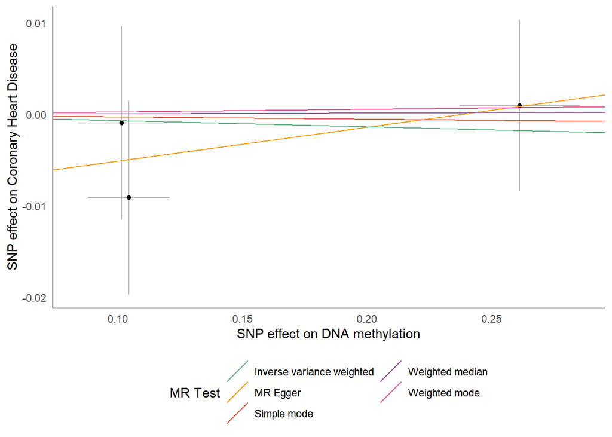

```r
library(ggplot2)

PLOT_7 <- mr_scatter_plot(mQTL_res_out_7, mQTL_vs_out_7)

#to make the plot my own the identifier needs to be named value

plotlot <- mQTL_res_out_7[1,1]
plotlot. <- ".7"

plottype <- paste0(plotlot, plotlot.)

PLOT_7 <- PLOT_7[[plottype]] + #COPY THE ID FROM THE MR TABLE!
  theme_minimal() +
  theme(legend.position="bottom",
        panel.background = element_rect(fill = "#FFFFFF",
                                        colour = "#FFFFFF"),
        panel.grid.major = element_blank(),
        panel.grid.minor = element_blank(),
        axis.line = element_line(colour = "black")) +
  labs(x = "SNP effect on DNA methylation") +
  labs(y = "SNP effect on Coronary Heart Disease") +
  scale_color_manual(values=c("#5EB17F","#F59D10","#E55738","#8D5B9A","#E35493"))

PLOT_7
```

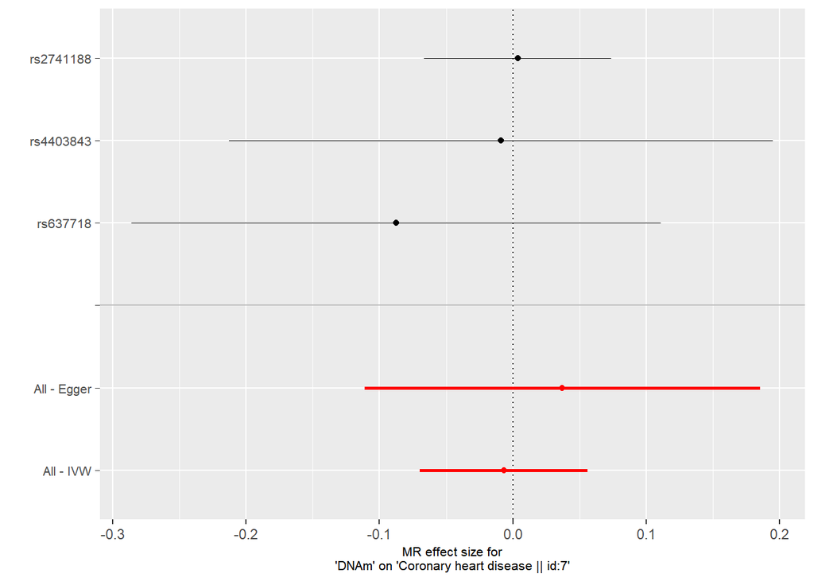

```r
#forestplot

PLOT_7_forest <- mr_forest_plot(res_single_out_7)
PLOT_7_forest[[1]]
```

### METASTROKE

2SMR analysis of shear stress associated DNA methylation on Stroke

#### 2SMR and horizontal pleiotropy results

```r
#plaque MR analysis with IS as outcome
#2SMR analyse

library(TwoSampleMR)
library(MRInstruments)
data("gwas_catalog")
ao <- available_outcomes()

#read data manually

write.csv(mQTL_data, "mQTL_data.csv")

mQTL_exposure_data <- read_exposure_data(
  filename = "mQTL_data.csv",
  sep = ",",
  snp_col = "VARIANT",
  beta_col = "Beta",
  se_col = "SE",
  effect_allele_col = "CodedAlleleA",
  other_allele_col = "OtherAlleleB",
  eaf_col = "MAF",
  pval_col = "Perm_P",
  gene_col = "GeneName",
  samplesize_col = "N"
)

mQTL_exposure_data$exposure <- "DNAm"

##MR on Coronary Artery Disease

#clumping

mQTL_exposure_data_clumped <- clump_data(mQTL_exposure_data)

#extract outcome data

out_dat_1108 <- extract_outcome_data(
  snps = mQTL_exposure_data_clumped$SNP,
  outcomes = 1108,                                           #enter your MR Base outcomes here
  proxies = TRUE
)

#harmonize data

mQTL_vs_out_1108 <- harmonise_data(
  exposure_dat = mQTL_exposure_data_clumped,
  outcome_dat = out_dat_1108
)


#MR analysis

mQTL_res_out_1108 <- mr(mQTL_vs_out_1108)

mQTL_res_out_1108 %>%
  kable() %>%
  kable_styling(bootstrap_options = c("striped", "condensed"), font_size = 12, fixed_thead = T)
```

| id.exposure | id.outcome | outcome | exposure | method | nsnp | b | se | pval |
| --- | --- | --- | --- | --- | --- | --- | --- | --- |
| 8vGiJC | 1108 | Ischemic stroke \|\| id:1108 | DNAm | Wald ratio | 1 | -0.1703645 | 0.1703645 | 0.3173105 |

```r
res_single_out_1108 <- mr_singlesnp(mQTL_vs_out_1108)

res_single_out_1108 %>%
  kable() %>%
  kable_styling(bootstrap_options = c("striped", "condensed"), font_size = 12, fixed_thead = T)
```

| exposure | outcome | id.exposure | id.outcome | samplesize | SNP | b | se | p |
| --- | --- | --- | --- | --- | --- | --- | --- | --- |
| DNAm | Ischemic stroke \|\| id:1108 | 8vGiJC | 1108 | 29633 | rs4403843 | -0.1703645 | 0.1703645 | 0.3173105 |
| DNAm | Ischemic stroke \|\| id:1108 | 8vGiJC | 1108 | 29633 | All - Inverse variance weighted | NA | NA | NA |
| DNAm | Ischemic stroke \|\| id:1108 | 8vGiJC | 1108 | 29633 | All - MR Egger | NA | NA | NA |

```r
# res_pleiotropy_1108 <- mr_pleiotropy_test(mQTL_vs_out_1108)
#
# res_pleiotropy_1108 %>%
#   kable() %>%
#   kable_styling(bootstrap_options = c("striped", "condensed"), font_size = 12, fixed_thead = T)
```

#### Scatter plot and forest plot with passing SNPs

Not enough SNPs for a plot.

## Regional Association Plot ENOSF1

We made the regional association plot of the ENOSF1 region using Regional Association ComparER (RACER) v0.1 of [oliviasabik](https://github.com/oliviasabik/RACER).

```
## [1] "https://analysistools.nci.nih.gov/LDlink/LDlinkRest/ldproxy?var=rs7235957&pop=EUR&r2_d=r2&token=c0f613f149ab"
```

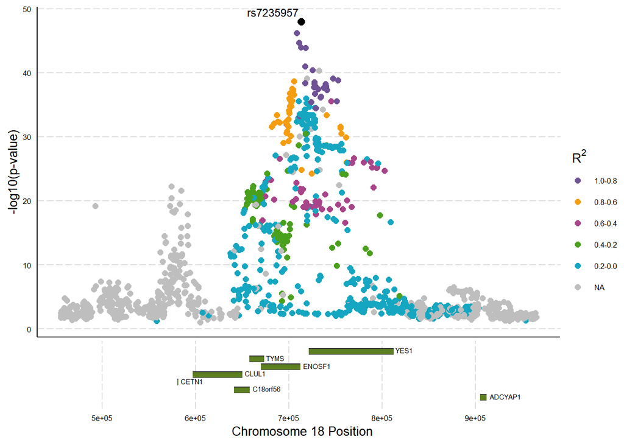

## Data availability

### CpG list

CpG list

### Nominal mQTL results

Available upon request

### Permutation mQTL results

Permutation mQTL results

### Gene regions for promoter filtering

Gene regions for filtering

## References

1. Verhoeven, B. A. N. et al. Athero-express: differential atherosclerotic plaque expression of mRNA and protein in relation to cardiovascular events and patient characteristics. Rationale and design. Eur. J. Epidemiol. 19, 1127–1133 (2004)
2. Nikpay, M. et al. A comprehensive 1,000 Genomes-based genome-wide association meta-analysis of coronary artery disease. Nat. Genet. 47, 1121–1130 (2015)
3. Malik, R. et al. Low-frequency and common genetic variation in ischemic stroke: The METASTROKE collaboration. Neurology 86, 1217–1226 (2016)
4. Delaneau, O. et al. A complete tool set for molecular QTL discovery and analysis. Nat Commun 8, 15452 (2017)
5. Davey Smith, G. & Hemani, G. Mendelian randomization: genetic anchors for causal inference in epidemiological studies. Hum. Mol. Genet. 23, R89-98 (2014)

| <sup>© 1998-2019 Ruben Methorst \| r.methorst[at]umcutrecht.nl.</sup> |
| --- |